# Kalman, Time series and Markov Chain

RR

12 luglio 2016

## Kalman

For more details on Kalman Filter see https://cran.r-project.org/web/packages/FKF/FKF.pdf.

Theory and explanation are done in this work https://www.jstatsoft.org/article/view/v039i02/v39i02.pdf

### First Example

```r
library("FKF",lib.loc="~/R/win-library/3.2")
## <--------------------------------------------------------------------------->
## Example 1: ARMA(2, 1) model estimation.
## <--------------------------------------------------------------------------->
## This example shows how to fit an ARMA(2, 1) model using this Kalman
## filter implementation (see also stats' makeARIMA and KalmanRun).
n <- 1000
## Set the AR parameters
ar1 <- 0.6
ar2 <- 0.2
ma1 <- -0.2
sigma <- sqrt(0.2)
## Sample from an ARMA(2, 1) process
a <- arima.sim(model = list(ar = c(ar1, ar2), ma = ma1), n = n,
innov = rnorm(n) * sigma)
## Create a state space representation out of the four ARMA parameters
arma21ss <- function(ar1, ar2, ma1, sigma) {
Tt <- matrix(c(ar1, ar2, 1, 0), ncol = 2)
Zt <- matrix(c(1, 0), ncol = 2)
ct <- matrix(0)
dt <- matrix(0, nrow = 2)
GGt <- matrix(0)
H <- matrix(c(1, ma1), nrow = 2) * sigma
HHt <- H %*% t(H)
a0 <- c(0, 0)
P0 <- matrix(1e6, nrow = 2, ncol = 2)
return(list(a0 = a0, P0 = P0, ct = ct, dt = dt, Zt = Zt, Tt = Tt, GGt = GGt, HHt = HHt))
}
## The objective function passed to 'optim'
objective <- function(theta, yt) {
sp <- arma21ss(theta["ar1"], theta["ar2"], theta["ma1"], theta["sigma"])
ans <- fkf(a0 = sp$a0, P0 = sp$P0, dt = sp$dt, ct = sp$ct, Tt = sp$Tt,
Zt = sp$Zt, HHt = sp$HHt, GGt = sp$GGt, yt = yt)
return(-ans$logLik)
}
theta <- c(ar = c(0, 0), ma1 = 0, sigma = 1)
fit <- optim(theta, objective, yt = rbind(a), hessian = TRUE)
fit
```

```
## $par
##        ar1        ar2        ma1      sigma
##  0.5861505  0.2032081 -0.1712842  0.4594871
##
## $value
## [1] 648.3971
##
## $counts
## function gradient
##      309       NA
##
## $convergence
## [1] 0
##
## $message
## NULL
##
## $hessian
##                ar1          ar2         ma1        sigma
## ar1   2274.2554852 1673.4822685 1117.514152   -0.6028627
## ar2   1673.4822685 2274.0862991  188.786385    0.1314226
## ma1   1117.5141520  188.7863847 1031.306513   -0.7162220
## sigma   -0.6028627    0.1314226   -0.716222 9461.4947711
```

```r
## Confidence intervals
rbind(fit$par - qnorm(0.975) * sqrt(diag(solve(fit$hessian))),
fit$par + qnorm(0.975) * sqrt(diag(solve(fit$hessian))))
```

```
##            ar1        ar2         ma1     sigma
## [1,] 0.3900171 0.06806104 -0.37001879 0.4393374
## [2,] 0.7822838 0.33835526  0.02745047 0.4796368
```

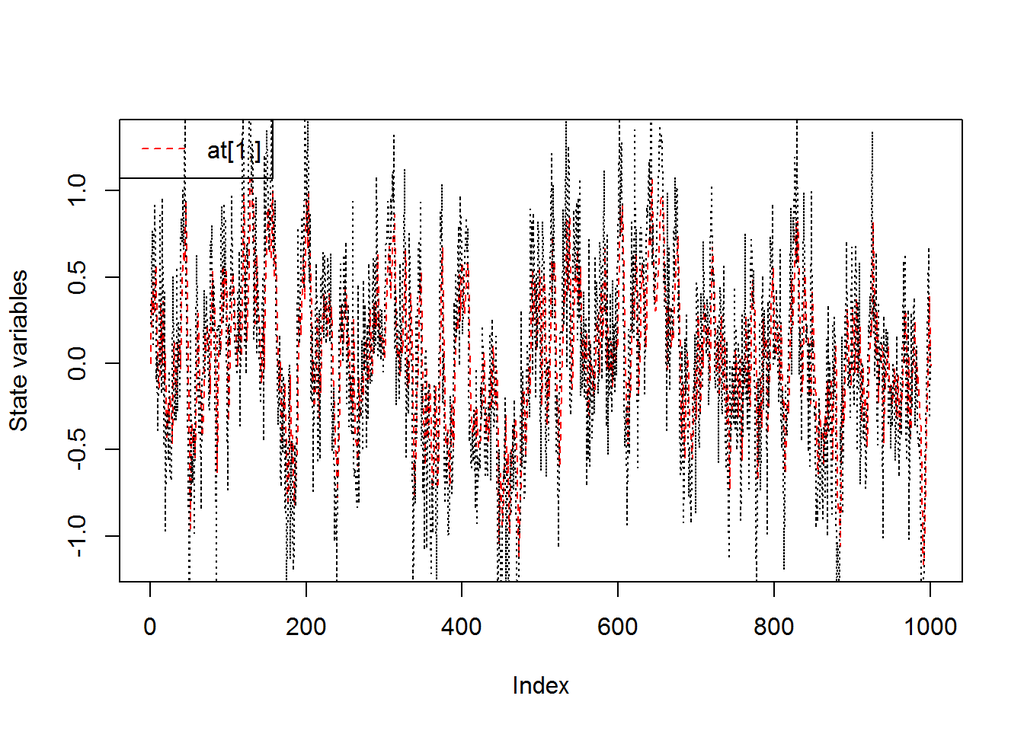

```r
## Filter the series with estimated parameter values
sp <- arma21ss(fit$par["ar1"], fit$par["ar2"], fit$par["ma1"], fit$par["sigma"])
ans <- fkf(a0 = sp$a0, P0 = sp$P0, dt = sp$dt, ct = sp$ct, Tt = sp$Tt,
Zt = sp$Zt, HHt = sp$HHt, GGt = sp$GGt, yt = rbind(a))
## Compare the prediction with the realization
plot(ans, at.idx = 1, att.idx = NA, CI = NA)
lines(a, lty = "dotted")
```

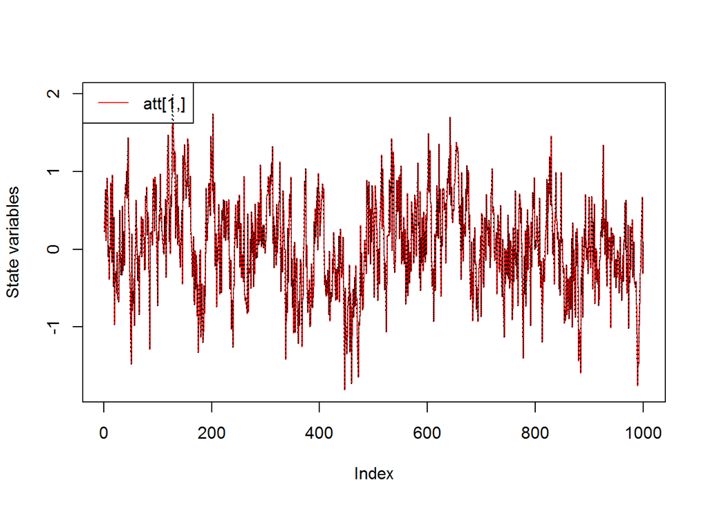

```r
## Compare the filtered series with the realization
plot(ans, at.idx = NA, att.idx = 1, CI = NA)
lines(a, lty = "dotted")
```

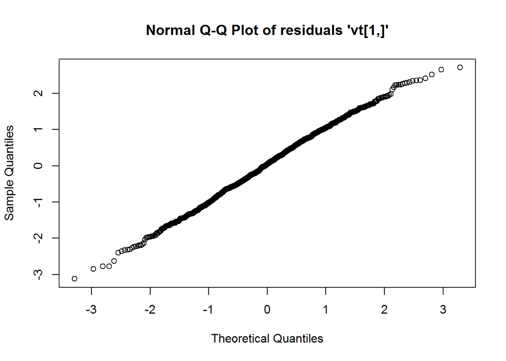

```r
## Check whether the residuals are Gaussian
plot(ans, type = "resid.qq")
```

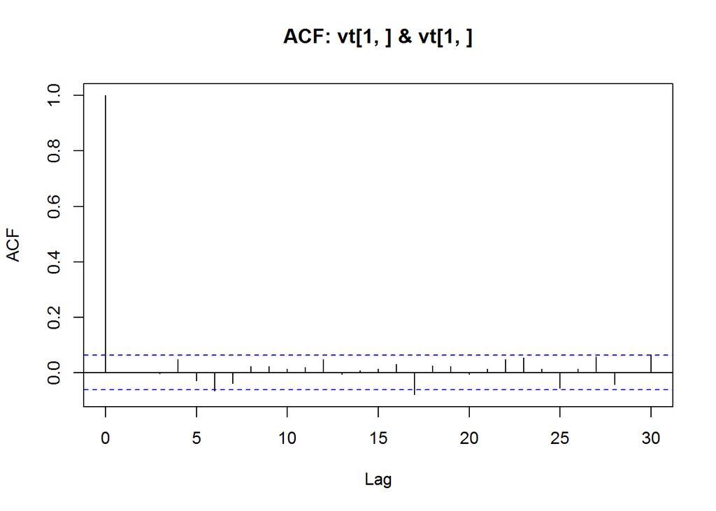

```r
## Check for linear serial dependence through 'acf'
plot(ans, type = "acf")
```

### Second Example

```r
library("FKF",lib.loc="~/R/win-library/3.2")
## <--------------------------------------------------------------------------->
## Example 2: Local level model for the Nile's annual flow.
## <--------------------------------------------------------------------------->
## Transition equation:
## alpha[t+1] = alpha[t] + eta[t], eta[t] ~ N(0, HHt)
## Measurement equation:
## y[t] = alpha[t] + eps[t], eps[t] ~ N(0, GGt)
y <- Nile
y[c(3, 10)] <- NA # NA values can be handled
## Set constant parameters:
dt <- ct <- matrix(0)
Zt <- Tt <- matrix(1)
a0 <- y[1] # Estimation of the first year flow
P0 <- matrix(100) # Variance of 'a0'
## Estimate parameters:
fit.fkf <- optim(c(HHt = var(y, na.rm = TRUE) * .5,
GGt = var(y, na.rm = TRUE) * .5),
fn = function(par, ...)
-fkf(HHt = matrix(par[1]), GGt = matrix(par[2]), ...)$logLik,
yt = rbind(y), a0 = a0, P0 = P0, dt = dt, ct = ct,
Zt = Zt, Tt = Tt, check.input = FALSE)
## Filter Nile data with estimated parameters:
fkf.obj <- fkf(a0, P0, dt, ct, Tt, Zt, HHt = matrix(fit.fkf$par[1]),
GGt = matrix(fit.fkf$par[2]), yt = rbind(y))
## Compare with the stats' structural time series implementation:
fit.stats <- StructTS(y, type = "level")
fit.fkf$par
```

```
##       HHt       GGt
##  1385.066 15124.131
```

```r
fit.stats$coef
```

```
##     level   epsilon
##  1599.452 14904.781
```

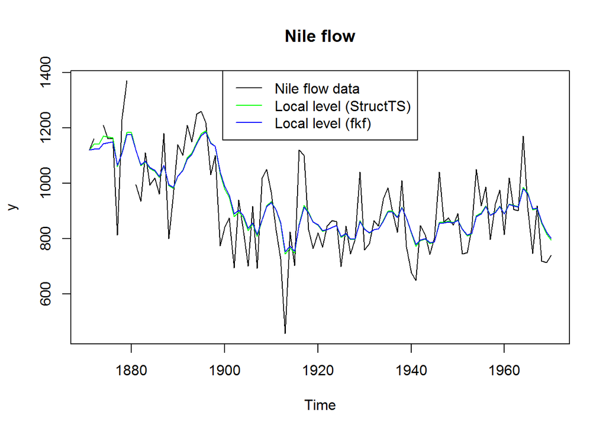

```r
## Plot the flow data together with fitted local levels:
plot(y, main = "Nile flow")
lines(fitted(fit.stats), col = "green")
lines(ts(fkf.obj$att[1, ], start = start(y), frequency = frequency(y)), col = "blue")
legend("top", c("Nile flow data", "Local level (StructTS)", "Local level (fkf)"),
col = c("black", "green", "blue"), lty = 1)
```

### Third Example

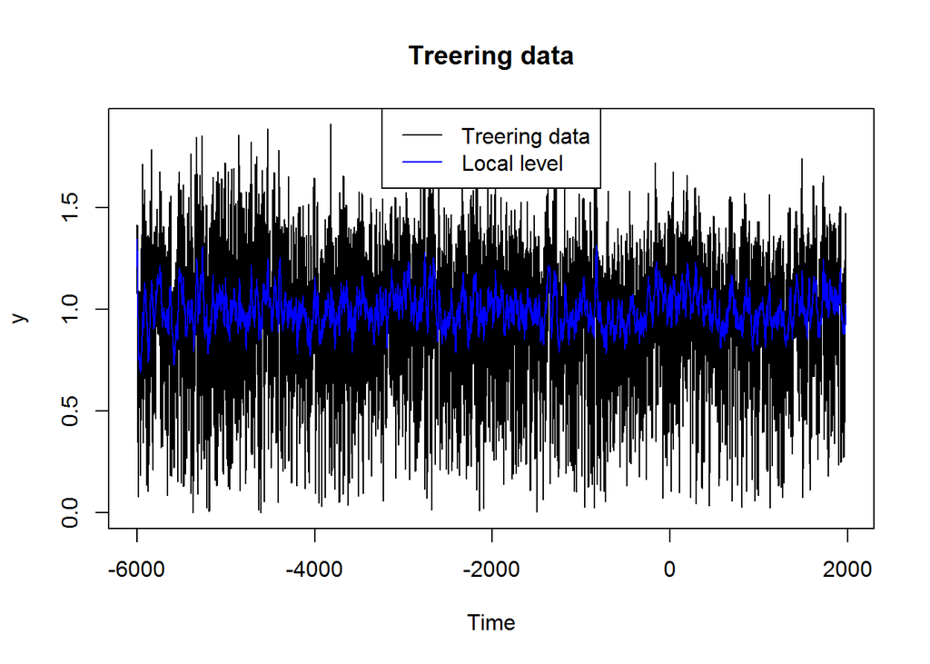

```r
library("FKF",lib.loc="~/R/win-library/3.2")
## Local level model for the treering width data.
## Transition equation:
## alpha[t+1] = alpha[t] + eta[t], eta[t] ~ N(0, HHt)
## Measurement equation:
## y[t] = alpha[t] + eps[t], eps[t] ~ N(0, GGt)
y <- treering
y[c(3, 10)] <- NA # NA values can be handled
## Set constant parameters:
dt <- ct <- matrix(0)
Zt <- Tt <- matrix(1)
a0 <- y[1] # Estimation of the first width
P0 <- matrix(100) # Variance of 'a0'
## Estimate parameters:
fit.fkf <- optim(c(HHt = var(y, na.rm = TRUE) * .5,
GGt = var(y, na.rm = TRUE) * .5),
fn = function(par, ...)
-fkf(HHt = matrix(par[1]), GGt = matrix(par[2]), ...)$logLik,
yt = rbind(y), a0 = a0, P0 = P0, dt = dt, ct = ct,
Zt = Zt, Tt = Tt, check.input = FALSE)
## Filter Nile data with estimated parameters:
fkf.obj <- fkf(a0, P0, dt, ct, Tt, Zt, HHt = matrix(fit.fkf$par[1]),
GGt = matrix(fit.fkf$par[2]), yt = rbind(y))
## Plot the width together with fitted local levels:
plot(y, main = "Treering data")
lines(ts(fkf.obj$att[1, ], start = start(y), frequency = frequency(y)), col = "blue")
legend("top", c("Treering data", "Local level"), col = c("black", "blue"), lty = 1)
```

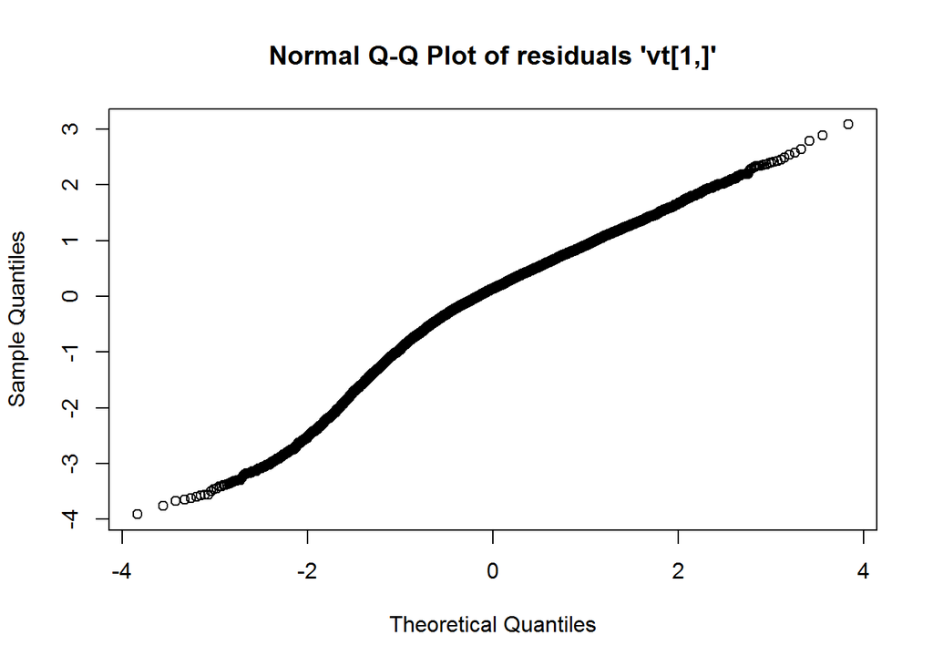

```r
## Check the residuals for normality:
plot(fkf.obj, type = "resid.qq")
```

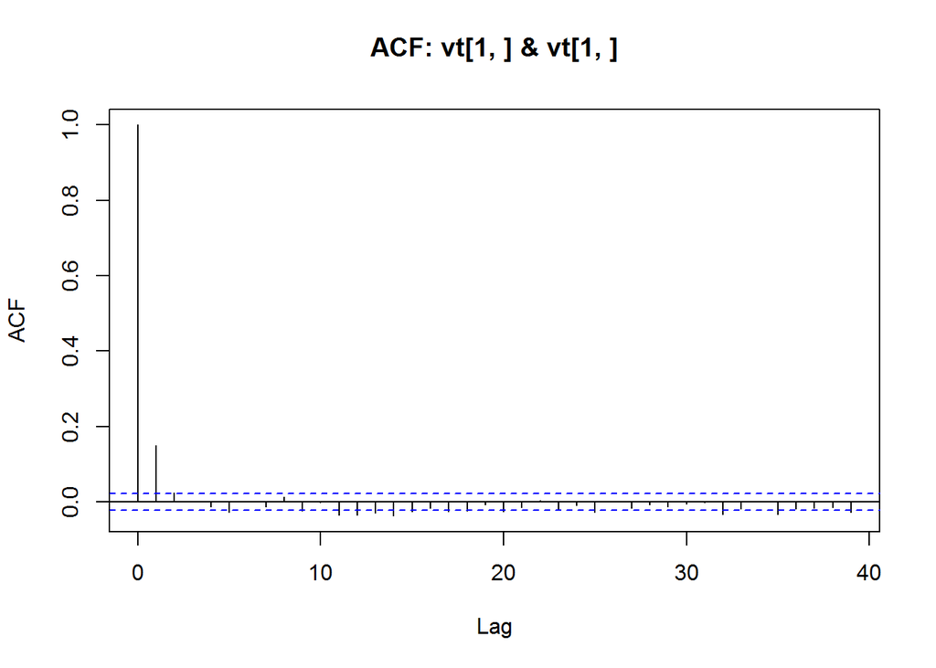

```r
## Test for autocorrelation:
plot(fkf.obj, type = "acf", na.action = na.pass)
```

## Time Series

https://cran.r-project.org/web/packages/timeSeries/timeSeries.pdf

```r
library("timeSeries", lib.loc="~/R/win-library/3.2")
## Load Microsoft Data Set -
x <- MSFT
## Aggregate by Weeks -
by <- timeSequence(from = start(x), to = end(x), by = "week")
aggregate(x, by, mean)
```

```
## GMT
##                Open     High      Low    Close   Volume
## 2000-09-27 63.43750 63.56250 59.81250 60.62500 53077800
## 2000-10-04 59.65000 60.07500 57.70000 58.55000 40680380
## 2000-10-11 54.97500 56.45000 54.16250 55.08750 36448900
## 2000-10-18 53.03750 54.25000 50.83750 52.13750 50631280
## 2000-10-25 61.78750 64.18750 60.08750 62.38750 86457340
## 2000-11-01 66.13750 68.78750 65.85000 67.93750 53496000
## 2000-11-08 69.83750 70.96876 68.68750 69.60000 53202820
## 2000-11-15 68.43750 70.08750 67.13124 68.71250 41280860
## 2000-11-22 68.08750 69.75000 67.13438 68.23750 41464220
## 2000-11-29 69.15625 69.89062 67.29688 68.17188 43184175
## 2000-12-06 59.30000 60.45000 56.51250 57.40000 57971300
## 2000-12-13 56.37500 57.82500 54.85000 56.25000 52329080
## 2000-12-20 49.64688 50.54688 47.20000 47.76250 56459820
## 2000-12-27 44.62500 46.90625 43.98438 45.79688 51083775
## 2001-01-03 44.09375 46.48438 43.21875 44.81250 49496525
## 2001-01-10 49.25000 51.31250 48.32500 50.23750 49082480
## 2001-01-17 53.71875 54.78125 52.12500 53.50000 39609175
## 2001-01-24 59.03750 60.60000 58.03750 60.02500 57656080
## 2001-01-31 62.96250 64.28750 61.98750 62.95000 40289680
## 2001-02-07 61.62500 63.38750 60.97500 62.47500 41679580
## 2001-02-14 60.22500 61.11250 58.43750 59.33750 39770480
## 2001-02-21 57.15625 58.68750 56.14062 57.06250 32158025
## 2001-02-28 57.46250 59.10312 56.48438 57.97500 46513080
## 2001-03-07 58.36250 59.47500 57.38750 58.72188 33749140
## 2001-03-14 55.52500 56.75626 53.82500 55.21250 45451820
## 2001-03-21 53.82500 55.21562 52.29688 53.06250 46233500
## 2001-03-28 55.21250 57.01250 54.33750 56.08750 46281860
## 2001-04-04 54.92500 56.12500 53.37500 54.23750 45234480
## 2001-04-11 57.05900 58.71450 56.34050 57.96150 48136060
## 2001-04-18 61.21750 63.07750 60.62750 62.47000 49402875
## 2001-04-25 67.99800 69.65800 67.10800 68.50600 61038700
## 2001-05-02 69.35800 70.23800 67.81800 68.78600 49124540
## 2001-05-09 70.21400 71.35600 69.48200 70.62400 44692860
## 2001-05-16 69.33200 69.92400 68.44800 69.11000 31371080
## 2001-05-23 68.93600 70.25600 68.24800 69.01200 47817480
## 2001-05-30 70.49000 71.50250 69.58250 70.54000 36405225
## 2001-06-06 70.65800 71.73200 69.79000 71.05200 34148380
## 2001-06-13 72.34800 73.00800 71.41800 72.35200 28818960
## 2001-06-20 68.20600 69.05000 66.95200 68.10600 36473940
## 2001-06-27 69.18600 70.54200 68.46600 69.76000 30218820
## 2001-07-04 71.62500 73.37750 70.50250 71.70250 40513375
## 2001-07-11 66.96600 67.80600 65.54000 66.24800 32357220
## 2001-07-18 70.96200 71.94400 70.28600 71.30200 36383520
## 2001-07-25 68.35000 69.43000 67.36400 68.52800 42234800
## 2001-08-01 66.32600 66.93000 65.54000 66.10400 30027700
## 2001-08-08 66.71800 67.26200 65.68400 66.33600 21163460
## 2001-08-15 65.09000 65.70800 63.92000 64.85000 20595220
## 2001-08-22 62.42200 63.18800 61.01800 62.12800 26973000
## 2001-08-29 61.11200 62.28400 59.98400 60.89400 25536780
## 2001-09-05 57.31500 58.79750 56.07000 56.95750 39024075
## 2001-09-12 55.86333 57.90000 55.30333 56.33333 47782067
## 2001-09-19 53.96333 54.93333 52.19000 53.70000 56272467
## 2001-09-26 50.94000 52.09200 49.55000 50.81000 53200500
```

```r
## Aggregate to Last Friday of Month -
by <- unique(timeLastNdayInMonth(time(x), 5))
X <- aggregate(x, by, mean)
X
```

```
## GMT
##                Open     High      Low    Close   Volume
## 2000-10-06 59.12500 59.74219 57.28906 58.03906 40990800
## 2000-11-03 60.40000 62.24219 59.11875 60.76875 56853450
## 2000-12-01 67.83553 69.25329 66.28043 67.41447 49085968
## 2001-01-05 50.33628 51.97215 48.82609 50.13315 51544465
## 2001-02-02 57.79605 59.25000 56.68092 58.19408 45374658
## 2001-03-02 58.83882 60.23108 57.66365 58.94984 40936453
## 2001-04-06 55.33250 56.79438 54.07938 55.34000 44278232
## 2001-05-04 65.47737 66.94895 64.54632 65.92053 51527416
## 2001-06-01 69.80053 70.71263 68.95895 69.79632 38750379
## 2001-07-06 70.33000 71.38375 69.25625 70.34208 33523921
## 2001-08-03 67.95050 68.81650 67.09000 68.03400 34769520
## 2001-08-31 62.90450 63.75150 61.67950 62.53450 25018965
## 2001-10-05 53.40357 54.79357 52.12071 53.42500 49792257
```

```r
dayOfWeek(time(X))
```

```
## 2000-10-06 2000-11-03 2000-12-01 2001-01-05 2001-02-02 2001-03-02
##      "Fri"      "Fri"      "Fri"      "Fri"      "Fri"      "Fri"
## 2001-04-06 2001-05-04 2001-06-01 2001-07-06 2001-08-03 2001-08-31
##      "Fri"      "Fri"      "Fri"      "Fri"      "Fri"      "Fri"
## 2001-10-05
##      "Fri"
```

```r
isMonthly(X)
```

```
## [1] FALSE
```

```r
## Aggregate to Last Day of Quarter -
by <- unique(timeLastDayInQuarter(time(x)))
X <- aggregate(x, by, mean)
X
```

```
## GMT
##                Open     High      Low    Close   Volume
## 2000-09-30 61.75000 62.25000 59.68750 60.75000 38761600
## 2000-12-31 59.66245 61.15799 58.15104 59.40476 51663067
## 2001-03-31 56.60282 58.10383 55.45111 56.83947 43853037
## 2001-06-30 67.47548 68.69083 66.53270 67.70242 42081671
## 2001-09-30 62.85552 63.81966 61.71155 62.67172 34511040
```

```r
isQuarterly(X)
```

```
## [1] TRUE
```

```r
## Aggregate daily records to end of month records -
X <- daily2monthly(x)
X
```

```
## GMT
##               Open    High     Low   Close   Volume
## 2000-09-30 61.0000 61.3125 58.6250 60.3125 37026800
## 2000-10-31 69.0000 69.5000 68.0000 68.8750 52237000
## 2000-11-30 62.0000 62.0625 57.0000 57.3750 98600400
## 2000-12-31 43.9375 45.8125 43.0000 43.3750 49988800
## 2001-01-31 63.0000 63.7500 61.0000 61.0625 40949400
## 2001-02-28 59.5625 60.0781 58.1875 59.0000 42304200
## 2001-03-31 55.7500 56.1875 53.8750 54.6875 45600800
## 2001-04-30 68.5300 69.0600 67.6800 67.7500 37184100
## 2001-05-31 69.4900 70.3800 68.4000 69.1800 35341300
## 2001-06-30 72.6000 73.4100 71.4000 73.0000 47141900
## 2001-07-31 66.0100 67.3900 65.8500 66.1900 29515800
## 2001-08-31 56.8500 58.0600 56.3000 57.0500 28950400
## 2001-09-30 50.1000 50.6800 48.0000 49.9600 40595600
```

```r
isMonthly(X)
```

```
## [1] TRUE
```

```r
## Aggregate da, ily records to end of week records -
X <- daily2weekly(x, startOn="Fri")
X
```

```
## GMT
##               Open    High     Low   Close    Volume
## 2000-09-29 61.0000 61.3125 58.6250 60.3125  37026800
## 2000-10-06 55.8125 56.7500 54.7500 55.5625  30897000
## 2000-10-13 53.8750 54.8750 52.1250 53.7500  52260600
## 2000-10-20 61.3125 66.1250 61.1250 65.1875  80189300
## 2000-10-27 64.6875 69.1875 64.6250 67.6875  62146200
## 2000-11-03 69.2500 69.6250 68.0625 68.2500  34355500
## 2000-11-10 69.9375 70.3125 66.8125 67.3750  46872200
## 2000-11-17 69.4375 70.0000 67.7969 69.0625  53262800
## 2000-11-24 69.0000 70.4375 68.5000 69.9375  17219600
## 2000-12-01 58.0625 60.6250 56.0625 56.6250  54904900
## 2000-12-08 54.6250 55.8750 53.4375 54.4375  60469900
## 2000-12-15 51.0469 52.0000 47.7500 49.1875  58449900
## 2000-12-22 44.7500 47.1250 44.7500 46.4375  54775900
## 2000-12-29 43.9375 45.8125 43.0000 43.3750  49988800
## 2001-01-05 48.5000 49.8750 47.5625 49.1250  46707300
## 2001-01-12 54.8750 55.0000 52.5000 53.5000  36856000
## 2001-01-19 60.0000 61.4375 58.8750 61.0000 104674400
## 2001-01-26 61.0000 64.3125 61.0000 64.0000  46540000
## 2001-02-02 62.5000 63.3750 60.7500 60.8125  35550000
## 2001-02-09 61.3125 61.5625 58.5000 59.1250  50287600
## 2001-02-16 57.0000 58.2500 56.1250 57.3125  33479200
## 2001-02-23 54.4375 57.5000 54.3125 56.7500  46310300
## 2001-03-02 57.5000 58.1250 56.4375 56.6875  39900400
## 2001-03-09 57.9375 58.1875 54.8750 56.6875  51897200
## 2001-03-16 52.5000 55.1250 52.4844 54.5625  56424400
## 2001-03-23 54.9375 57.0000 54.3750 56.5625  49759800
## 2001-03-30 55.7500 56.1875 53.8750 54.6875  45600800
## 2001-04-06 56.3750 57.1875 55.0625 56.1875  46311000
## 2001-04-13 59.5600 62.3100 59.3500 62.1800  43760000
## 2001-04-20 70.3000 71.1000 68.5000 69.0000  96459800
## 2001-04-27 69.5300 69.6800 66.2100 67.1200  60786200
## 2001-05-04 68.0000 71.0500 67.9600 70.7500  59769200
## 2001-05-11 69.9600 70.0000 68.6500 69.4000  25564400
## 2001-05-18 67.6900 69.2000 67.2500 68.0900  45302700
## 2001-05-25 71.6600 71.9000 70.3600 70.9100  26373800
## 2001-06-01 69.6000 70.7000 68.7000 70.3400  28793800
## 2001-06-08 73.7000 73.7500 72.0500 73.1900  25933500
## 2001-06-15 67.5100 68.3000 66.4000 68.0200  54177200
## 2001-06-22 70.0000 70.6100 68.5800 68.8300  25546000
## 2001-06-29 72.6000 73.4100 71.4000 73.0000  47141900
## 2001-07-06 68.3000 68.4000 65.6700 66.0600  33733900
## 2001-07-13 71.4000 72.0000 70.9400 71.3400  29467300
## 2001-07-20 68.0300 69.4000 67.9400 69.1800  62101800
## 2001-07-27 66.0500 66.2500 65.0500 65.4700  32698000
## 2001-08-03 67.3000 67.3600 66.0000 66.8900  21630200
## 2001-08-10 64.7700 65.8600 62.9000 65.5200  25878200
## 2001-08-17 63.7800 64.1300 61.5000 61.8800  26117100
## 2001-08-24 59.6000 62.2800 59.2300 62.0500  31699500
## 2001-08-31 56.8500 58.0600 56.3000 57.0500  28950400
## 2001-09-07 56.1100 57.3600 55.3100 55.4000  44931900
## 2001-09-14 54.9200 57.9500 54.7000 57.5800  42235900
## 2001-09-21 47.9200 50.6000 47.5000 49.7100  92488300
```

```r
dayOfWeek(time(X))
```

```
## 2000-09-29 2000-10-06 2000-10-13 2000-10-20 2000-10-27 2000-11-03
##      "Fri"      "Fri"      "Fri"      "Fri"      "Fri"      "Fri"
## 2000-11-10 2000-11-17 2000-11-24 2000-12-01 2000-12-08 2000-12-15
##      "Fri"      "Fri"      "Fri"      "Fri"      "Fri"      "Fri"
## 2000-12-22 2000-12-29 2001-01-05 2001-01-12 2001-01-19 2001-01-26
##      "Fri"      "Fri"      "Fri"      "Fri"      "Fri"      "Fri"
## 2001-02-02 2001-02-09 2001-02-16 2001-02-23 2001-03-02 2001-03-09
##      "Fri"      "Fri"      "Fri"      "Fri"      "Fri"      "Fri"
## 2001-03-16 2001-03-23 2001-03-30 2001-04-06 2001-04-13 2001-04-20
##      "Fri"      "Fri"      "Fri"      "Fri"      "Fri"      "Fri"
## 2001-04-27 2001-05-04 2001-05-11 2001-05-18 2001-05-25 2001-06-01
##      "Fri"      "Fri"      "Fri"      "Fri"      "Fri"      "Fri"
## 2001-06-08 2001-06-15 2001-06-22 2001-06-29 2001-07-06 2001-07-13
##      "Fri"      "Fri"      "Fri"      "Fri"      "Fri"      "Fri"
## 2001-07-20 2001-07-27 2001-08-03 2001-08-10 2001-08-17 2001-08-24
##      "Fri"      "Fri"      "Fri"      "Fri"      "Fri"      "Fri"
## 2001-08-31 2001-09-07 2001-09-14 2001-09-21
##      "Fri"      "Fri"      "Fri"      "Fri"
```

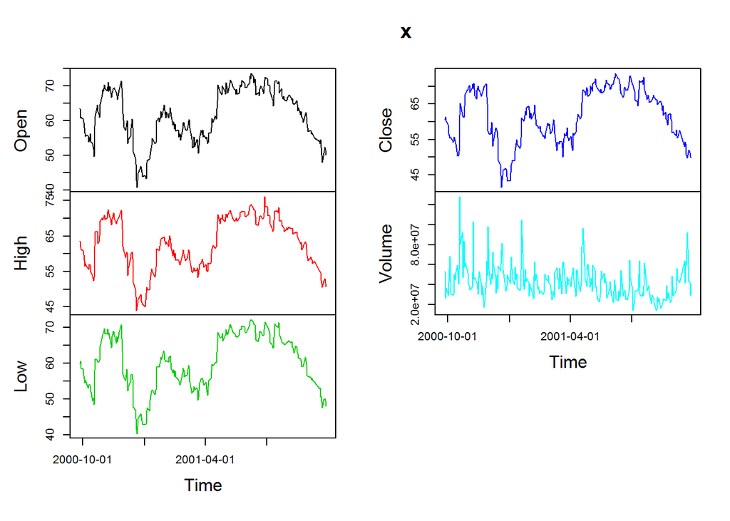

```r
plot(x)
```

### First Example

```r
library("timeSeries", lib.loc="~/R/win-library/3.2")
## Use MSFT and Compute Sample Size -
dim(MSFT)
```

```
## [1] 249   5
```

```r
## Align the Series -
MSFT.AL <- align(MSFT)
## Show the Size of the Aligned Series -
dim(MSFT.AL)
```

```
## [1] 262   5
```

### Second Example

```r
library("timeSeries", lib.loc="~/R/win-library/3.2")
## Percentual Returns of Swiss Bond Index and Performance Index -
LPP <- 100 * LPP2005REC[, c("SBI", "SPI")]
head(LPP, 20)
```

```
## GMT
##                   SBI        SPI
## 2005-11-01 -0.0612745  0.8414595
## 2005-11-02 -0.2762009  0.2519342
## 2005-11-03 -0.1153092  1.2707292
## 2005-11-04 -0.3235750 -0.0702757
## 2005-11-07  0.1310970  0.6205226
## 2005-11-08  0.0539312  0.0329260
## 2005-11-09 -0.2545021 -0.2378200
## 2005-11-10  0.1003358  0.0922087
## 2005-11-11  0.0616951  1.3334906
## 2005-11-14  0.0693615 -0.4693064
## 2005-11-15  0.0154071  0.1266865
## 2005-11-16  0.2999656 -0.7187498
## 2005-11-17 -0.1306436  0.7658103
## 2005-11-18 -0.2232573  1.2527202
## 2005-11-21  0.1155402  0.2659666
## 2005-11-22 -0.0230974  0.2142494
## 2005-11-23  0.0692761  0.3567128
## 2005-11-24  0.2075407 -0.2559544
## 2005-11-25 -0.0614487  0.3374818
## 2005-11-28 -0.0307385 -0.9816739
```

```r
## Aggregate Quarterly Returns -
applySeries(LPP, by = "quarterly", FUN = colSums)
```

```
## GMT
##                   SBI       SPI
## 2005-12-31  0.5193189  7.295300
## 2006-03-31 -1.6590275  7.074801
## 2006-06-30 -1.1685058 -3.428832
## 2006-09-30  2.7589662  9.780371
## 2006-12-31 -0.0076177  5.359906
## 2007-03-31 -0.2595182  3.604943
## 2007-06-30 -0.1682858  2.047652
```

```r
## Aggregate Quarterly every last Friday in Quarter -
oneDay <- 24*3600
from <- unique(timeFirstDayInQuarter(time(LPP))) - oneDay
from <- timeLastNdayInMonth(from, nday = 5)
to <- unique(timeLastDayInQuarter(time(LPP)))
to <- timeLastNdayInMonth(to, nday = 5)
data.frame(from = as.character(from), to = as.character(to))
```

```
##         from         to
## 1 2005-09-30 2006-01-06
## 2 2006-01-06 2006-03-31
## 3 2006-03-31 2006-06-30
## 4 2006-06-30 2006-10-06
## 5 2006-10-06 2007-01-05
## 6 2007-01-05 2007-04-06
## 7 2007-04-06 2007-07-06
```

```r
applySeries(LPP, from, to, FUN = colSums)
```

```
## GMT
##                   SBI        SPI
## 2006-01-06  0.4049956  9.1654132
## 2006-03-31 -1.5828270  5.4274690
## 2006-06-30 -1.1452689 -3.5217575
## 2006-10-06  2.7803272 12.2731914
## 2007-01-05 -0.2667938  5.6541189
## 2007-04-06 -0.5571005  3.6277826
## 2007-07-06 -0.0382716  0.5285255
```

```r
## Count Trading Days per Month -
colCounts <- function(x) rep(NROW(x), times = NCOL(x))
applySeries(LPP, FUN = colCounts, by = "monthly")
```

```
## GMT
##            SBI SPI
## 2005-11-30  22  22
## 2005-12-31  22  22
## 2006-01-31  22  22
## 2006-02-28  20  20
## 2006-03-31  23  23
## 2006-04-30  20  20
## 2006-05-31  23  23
## 2006-06-30  22  22
## 2006-07-31  21  21
## 2006-08-31  23  23
## 2006-09-30  21  21
## 2006-10-31  22  22
## 2006-11-30  22  22
## 2006-12-31  21  21
## 2007-01-31  23  23
## 2007-02-28  20  20
## 2007-03-31  22  22
## 2007-04-30   8   8
```

```r
## Alternative Use -
fapply(LPP, from, to, FUN = colSums)
```

```
## GMT
##                   SBI        SPI
## 2006-01-06  0.4049956  9.1654132
## 2006-03-31 -1.5828270  5.4274690
## 2006-06-30 -1.1452689 -3.5217575
## 2006-10-06  2.7803272 12.2731914
## 2007-01-05 -0.2667938  5.6541189
## 2007-04-06 -0.5571005  3.6277826
## 2007-07-06 -0.0382716  0.5285255
```

### Third Example

```r
library("timeSeries", lib.loc="~/R/win-library/3.2")
## Create an Artificial timeSeries Object -
setRmetricsOptions(myFinCenter = "GMT")
charvec <- timeCalendar()
data <- matrix(rnorm(12))
TS <- timeSeries(data, charvec, units = "RAND")
TS
```

```
## GMT
##                   RAND
## 2016-01-01  0.50796378
## 2016-02-01 -0.04672131
## 2016-03-01 -0.48722815
## 2016-04-01  1.25912087
## 2016-05-01  1.37166916
## 2016-06-01 -0.69913035
## 2016-07-01 -0.93185665
## 2016-08-01 -1.94196137
## 2016-09-01 -0.72232099
## 2016-10-01  2.26448548
## 2016-11-01  0.15935552
## 2016-12-01 -0.81045360
```

```r
## Coerce to Vector -
as.vector(TS)
```

```
##  [1]  0.50796378 -0.04672131 -0.48722815  1.25912087  1.37166916
##  [6] -0.69913035 -0.93185665 -1.94196137 -0.72232099  2.26448548
## [11]  0.15935552 -0.81045360
```

```r
## Coerce to Matrix -
as.matrix(TS)
```

```
##                   RAND
## 2016-01-01  0.50796378
## 2016-02-01 -0.04672131
## 2016-03-01 -0.48722815
## 2016-04-01  1.25912087
## 2016-05-01  1.37166916
## 2016-06-01 -0.69913035
## 2016-07-01 -0.93185665
## 2016-08-01 -1.94196137
## 2016-09-01 -0.72232099
## 2016-10-01  2.26448548
## 2016-11-01  0.15935552
## 2016-12-01 -0.81045360
```

```r
## Coerce to Data Frame -
as.data.frame(TS)
```

```
##                   RAND
## 2016-01-01  0.50796378
## 2016-02-01 -0.04672131
## 2016-03-01 -0.48722815
## 2016-04-01  1.25912087
## 2016-05-01  1.37166916
## 2016-06-01 -0.69913035
## 2016-07-01 -0.93185665
## 2016-08-01 -1.94196137
## 2016-09-01 -0.72232099
## 2016-10-01  2.26448548
## 2016-11-01  0.15935552
## 2016-12-01 -0.81045360
```

### Fourth Example

```r
library("timeSeries", lib.loc="~/R/win-library/3.2")
## Load Microsoft Data Set -
x <- MSFT[1:10, ]
colnames(x)
```

```
## [1] "Open"   "High"   "Low"    "Close"  "Volume"
```

```r
## Attach the Series and Compute the Range -
attach(x)
range <- High - Low
range
```

```
##  [1] 3.7500 1.2500 2.6875 2.5625 3.3125 2.0625 2.0000 2.0000 2.7500 1.7500
```

```r
## Convert Vector to a timeSeries Object -
timeSeries(data=range, charvec=time(x), units="Range")
```

```
## GMT
##             Range
## 2000-09-27 3.7500
## 2000-09-28 1.2500
## 2000-09-29 2.6875
## 2000-10-02 2.5625
## 2000-10-03 3.3125
## 2000-10-04 2.0625
## 2000-10-05 2.0000
## 2000-10-06 2.0000
## 2000-10-09 2.7500
## 2000-10-10 1.7500
```

```r
## Detach the series from the search path -

ans <- try(High, silent=TRUE)
cat(ans[1])
```

```
## 63.5625
```

```r
detach("x")
```

### Fifth Example

```r
library("timeSeries", lib.loc="~/R/win-library/3.2")
## Create an artificial timeSeries Object -
tS <- dummySeries()
tS
```

```
## GMT
##                  TS.1       TS.2
## 2016-01-01 0.33079885 0.33811951
## 2016-02-01 0.06208693 0.60844059
## 2016-03-01 0.71929688 0.99304262
## 2016-04-01 0.31749445 0.15871492
## 2016-05-01 0.21706651 0.03927450
## 2016-06-01 0.48826769 0.81750438
## 2016-07-01 0.38175548 0.70825109
## 2016-08-01 0.44947234 0.09535926
## 2016-09-01 0.11009216 0.33047408
## 2016-10-01 0.53502903 0.58715081
## 2016-11-01 0.91003267 0.35455286
## 2016-12-01 0.28820619 0.90588839
```

```r
## Get Optional Attributes -
getAttributes(tS)
```

[output not shown]

```r
tS@documentation
```

```
## [1] "Thu Jul 21 11:09:34 2016"
```

```r
## Set a new Optional Attribute -
setAttributes(tS) <- list(what="A dummy Series")
tS
```

```
## GMT
##                  TS.1       TS.2
## 2016-01-01 0.33079885 0.33811951
## 2016-02-01 0.06208693 0.60844059
## 2016-03-01 0.71929688 0.99304262
## 2016-04-01 0.31749445 0.15871492
## 2016-05-01 0.21706651 0.03927450
## 2016-06-01 0.48826769 0.81750438
## 2016-07-01 0.38175548 0.70825109
## 2016-08-01 0.44947234 0.09535926
## 2016-09-01 0.11009216 0.33047408
## 2016-10-01 0.53502903 0.58715081
## 2016-11-01 0.91003267 0.35455286
## 2016-12-01 0.28820619 0.90588839
```

```r
getAttributes(tS)
```

```
## $what
## $what[[1]]
## [1] "A dummy Series"
```

```r
tS@documentation
```

```
## [1] "Thu Jul 21 11:09:34 2016"
## attr(,"Attributes")
## attr(,"Attributes")$what
## attr(,"Attributes")$what[[1]]
## [1] "A dummy Series"
```

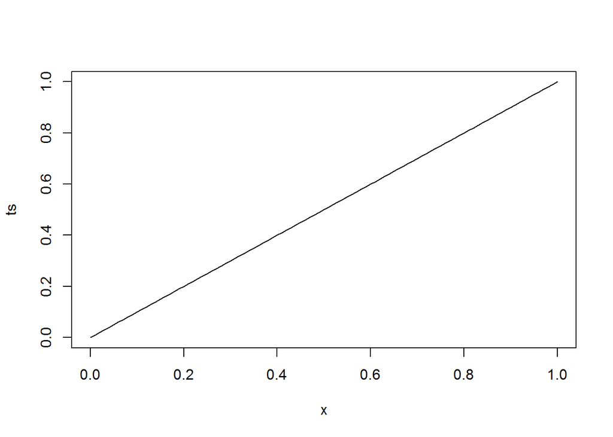

```r
plot(ts)
```

### Sixth Example

```r
library("timeSeries", lib.loc="~/R/win-library/3.2")
## Load Microsoft Data Set -
x <- MSFT[1:12, ]
x
```

```
## GMT
##               Open    High     Low   Close   Volume
## 2000-09-27 63.4375 63.5625 59.8125 60.6250 53077800
## 2000-09-28 60.8125 61.8750 60.6250 61.3125 26180200
## 2000-09-29 61.0000 61.3125 58.6250 60.3125 37026800
## 2000-10-02 60.5000 60.8125 58.2500 59.1250 29281200
## 2000-10-03 59.5625 59.8125 56.5000 56.5625 42687000
## 2000-10-04 56.3750 56.5625 54.5000 55.4375 68226700
## 2000-10-05 55.5000 57.2500 55.2500 55.3750 40549700
## 2000-10-06 55.8125 56.7500 54.7500 55.5625 30897000
## 2000-10-09 55.6250 55.7500 53.0000 54.1875 29161800
## 2000-10-10 53.9375 55.5625 53.8125 54.5625 31033100
## 2000-10-11 54.0000 56.9375 54.0000 55.7500 50602900
## 2000-10-12 56.3125 56.8750 53.8125 54.3750 45109800
```

```r
## Bind Columnwise -
X <- cbind(x[, "Open"], returns(x[, "Open"]))
colnames(X) <- c("Open", "Return")
X
```

```
## GMT
##               Open       Return
## 2000-09-27 63.4375           NA
## 2000-09-28 60.8125 -0.042259809
## 2000-09-29 61.0000  0.003078504
## 2000-10-02 60.5000 -0.008230499
## 2000-10-03 59.5625 -0.015617184
## 2000-10-04 56.3750 -0.055000384
## 2000-10-05 55.5000 -0.015642777
## 2000-10-06 55.8125  0.005614838
## 2000-10-09 55.6250 -0.003365118
## 2000-10-10 53.9375 -0.030806772
## 2000-10-11 54.0000  0.001158078
## 2000-10-12 56.3125  0.041932489
```

```r
## Bind Rowwise -
Y <- rbind(x[1:3, "Open"], x[10:12, "Open"])
Y
```

```
## GMT
##            Open_Open
## 2000-09-27   63.4375
## 2000-09-28   60.8125
## 2000-09-29   61.0000
## 2000-10-10   53.9375
## 2000-10-11   54.0000
## 2000-10-12   56.3125
```

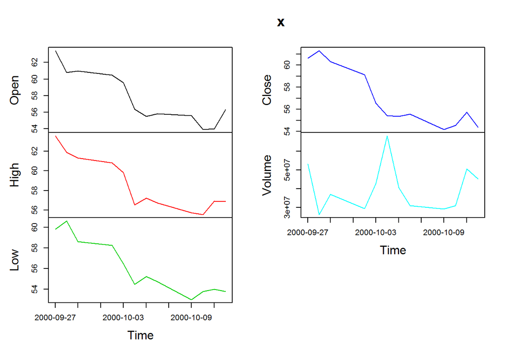

```r
plot(x)
```

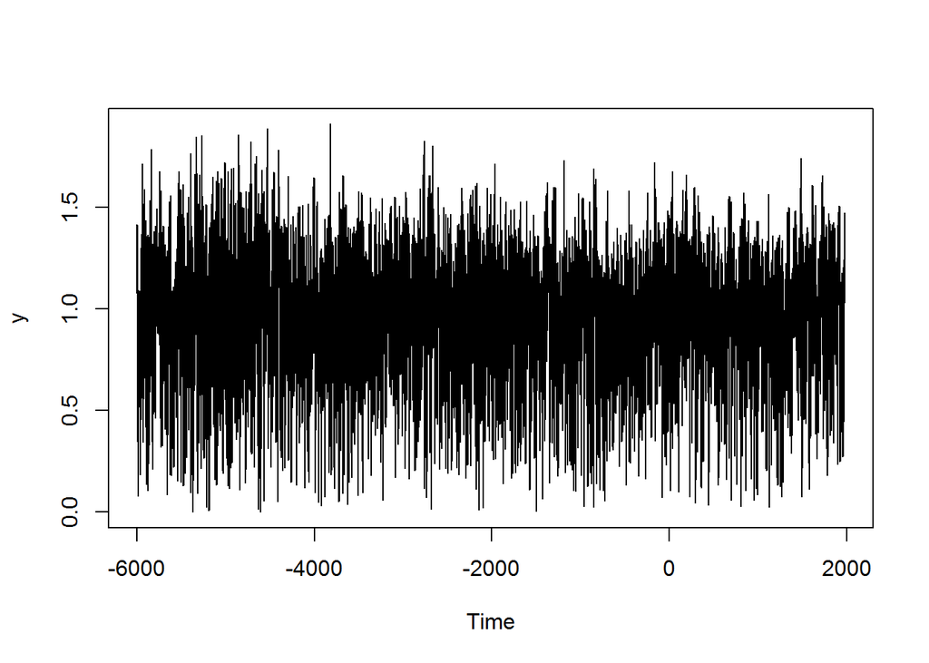

```r
plot(y)
```

### Seventh Example

```r
library("timeSeries", lib.loc="~/R/win-library/3.2")
## Simulated Return Data -
x = matrix(rnorm(24), ncol = 2)
## Cumulative Sums Column by Column -
colCumsums(x)
```

```
##             [,1]      [,2]
##  [1,] -1.0716189 0.2036372
##  [2,] -0.1687012 0.3289977
##  [3,] -0.4183559 0.9495539
##  [4,]  0.1896161 1.0887457
##  [5,]  2.1050767 3.7410309
##  [6,]  2.8028890 3.1554641
##  [7,]  3.0465509 2.6890107
##  [8,]  3.2117185 3.7107187
##  [9,]  2.0043216 4.3895792
## [10,]  1.3455310 5.1030713
## [11,]  0.4799977 4.3358833
## [12,] -0.0474248 3.7955695
```

### Eighth Example

```r
## Simulated Return Data in Matrix Form -
x = matrix(rnorm(252), ncol = 2)
## Mean Columnwise Statistics -
colStats(x, FUN = mean)
```

```
## [1] 0.01186580 0.03924747
```

```r
## Quantiles Column by Column -
colQuantiles(x, prob = 0.10, type = 1)
```

```
## [1] -1.299085 -1.165138
```

### Nineth Example

```r
library("timeSeries", lib.loc="~/R/win-library/3.2")
## Get Description from timeSeries -
comment(LPP2005REC)
```

```
## [1] "Thu Aug 27 17:27:15 2009"
```

```r
## Add User to comment -
comment(LPP2005REC) <- paste(comment(LPP2005REC), "by User Rmetrics")
comment(LPP2005REC)
```

```
## [1] "Thu Aug 27 17:27:15 2009 by User Rmetrics"
```

### Tenth Example

```r
library("timeSeries", lib.loc="~/R/win-library/3.2")
## Use the Microsofts' Close Prices Indexed to 1 -
MSFT.CL <- MSFT[, "Close"]
MSFT.CL <- MSFT.CL/MSFT[[1, "Close"]]
head(MSFT.CL)
```

```
## GMT
##                Close
## 2000-09-27 1.0000000
## 2000-09-28 1.0113402
## 2000-09-29 0.9948454
## 2000-10-02 0.9752577
## 2000-10-03 0.9329897
## 2000-10-04 0.9144330
```

```r
## Compute Discrete Return -
MSFT.RET <- returns(MSFT.CL, method = "discrete")
## Cumulated Series and Compare -
MSFT.CUM <- cumulated(MSFT.RET, method = "discrete")
head(cbind(MSFT.CL, MSFT.CUM))
```

```
## GMT
##              Close.1   Close.2
## 2000-09-27 1.0000000        NA
## 2000-09-28 1.0113402 1.0113402
## 2000-09-29 0.9948454 0.9948454
## 2000-10-02 0.9752577 0.9752577
## 2000-10-03 0.9329897 0.9329897
## 2000-10-04 0.9144330 0.9144330
```

### Eleventh Example

```r
library("timeSeries", lib.loc="~/R/win-library/3.2")
## Load Microsoft Data -
X <- MSFT[1:10, 1:4]
## Get Data Part -
DATA <- getDataPart(X)
class(DATA)
```

```
## [1] "matrix"
```

### Twelveth Example

```r
library("timeSeries", lib.loc="~/R/win-library/3.2")
## Load Microsoft Data Set -
x <- MSFT[1:12, ]
x
```

```
## GMT
##               Open    High     Low   Close   Volume
## 2000-09-27 63.4375 63.5625 59.8125 60.6250 53077800
## 2000-09-28 60.8125 61.8750 60.6250 61.3125 26180200
## 2000-09-29 61.0000 61.3125 58.6250 60.3125 37026800
## 2000-10-02 60.5000 60.8125 58.2500 59.1250 29281200
## 2000-10-03 59.5625 59.8125 56.5000 56.5625 42687000
## 2000-10-04 56.3750 56.5625 54.5000 55.4375 68226700
## 2000-10-05 55.5000 57.2500 55.2500 55.3750 40549700
## 2000-10-06 55.8125 56.7500 54.7500 55.5625 30897000
## 2000-10-09 55.6250 55.7500 53.0000 54.1875 29161800
## 2000-10-10 53.9375 55.5625 53.8125 54.5625 31033100
## 2000-10-11 54.0000 56.9375 54.0000 55.7500 50602900
## 2000-10-12 56.3125 56.8750 53.8125 54.3750 45109800
```

```r
## Compute Differences -
diff(x)
```

```
## GMT
##               Open    High     Low   Close    Volume
## 2000-09-27      NA      NA      NA      NA        NA
## 2000-09-28 -2.6250 -1.6875  0.8125  0.6875 -26897600
## 2000-09-29  0.1875 -0.5625 -2.0000 -1.0000  10846600
## 2000-10-02 -0.5000 -0.5000 -0.3750 -1.1875  -7745600
## 2000-10-03 -0.9375 -1.0000 -1.7500 -2.5625  13405800
## 2000-10-04 -3.1875 -3.2500 -2.0000 -1.1250  25539700
## 2000-10-05 -0.8750  0.6875  0.7500 -0.0625 -27677000
## 2000-10-06  0.3125 -0.5000 -0.5000  0.1875  -9652700
## 2000-10-09 -0.1875 -1.0000 -1.7500 -1.3750  -1735200
## 2000-10-10 -1.6875 -0.1875  0.8125  0.3750   1871300
## 2000-10-11  0.0625  1.3750  0.1875  1.1875  19569800
## 2000-10-12  2.3125 -0.0625 -0.1875 -1.3750  -5493100
```

```r
## Trimmed Differences -
diff(x, trim=TRUE)
```

```
## GMT
##               Open    High     Low   Close    Volume
## 2000-09-28 -2.6250 -1.6875  0.8125  0.6875 -26897600
## 2000-09-29  0.1875 -0.5625 -2.0000 -1.0000  10846600
## 2000-10-02 -0.5000 -0.5000 -0.3750 -1.1875  -7745600
## 2000-10-03 -0.9375 -1.0000 -1.7500 -2.5625  13405800
## 2000-10-04 -3.1875 -3.2500 -2.0000 -1.1250  25539700
## 2000-10-05 -0.8750  0.6875  0.7500 -0.0625 -27677000
## 2000-10-06  0.3125 -0.5000 -0.5000  0.1875  -9652700
## 2000-10-09 -0.1875 -1.0000 -1.7500 -1.3750  -1735200
## 2000-10-10 -1.6875 -0.1875  0.8125  0.3750   1871300
## 2000-10-11  0.0625  1.3750  0.1875  1.1875  19569800
## 2000-10-12  2.3125 -0.0625 -0.1875 -1.3750  -5493100
```

```r
## Padded Differences -
diff(x, trim=FALSE, pad=0)
```

```
## GMT
##               Open    High     Low   Close    Volume
## 2000-09-27  0.0000  0.0000  0.0000  0.0000         0
## 2000-09-28 -2.6250 -1.6875  0.8125  0.6875 -26897600
## 2000-09-29  0.1875 -0.5625 -2.0000 -1.0000  10846600
## 2000-10-02 -0.5000 -0.5000 -0.3750 -1.1875  -7745600
## 2000-10-03 -0.9375 -1.0000 -1.7500 -2.5625  13405800
## 2000-10-04 -3.1875 -3.2500 -2.0000 -1.1250  25539700
## 2000-10-05 -0.8750  0.6875  0.7500 -0.0625 -27677000
## 2000-10-06  0.3125 -0.5000 -0.5000  0.1875  -9652700
## 2000-10-09 -0.1875 -1.0000 -1.7500 -1.3750  -1735200
## 2000-10-10 -1.6875 -0.1875  0.8125  0.3750   1871300
## 2000-10-11  0.0625  1.3750  0.1875  1.1875  19569800
## 2000-10-12  2.3125 -0.0625 -0.1875 -1.3750  -5493100
```

### Thirteenth Example

```r
library("timeSeries", lib.loc="~/R/win-library/3.2")
## Load Swiss Pension Fund Benchmark Data -
X <- LPP2005REC[1:10, 1:3]
## Get Dimension -
dim(X)
```

```
## [1] 10  3
```

```r
## Get Column and Row Names -
dimnames(X)
```

```
## [[1]]
##  [1] "2005-11-01" "2005-11-02" "2005-11-03" "2005-11-04" "2005-11-07"
##  [6] "2005-11-08" "2005-11-09" "2005-11-10" "2005-11-11" "2005-11-14"
##
## [[2]]
## [1] "SBI" "SPI" "SII"
```

```r
## Get Column / Row Names -
colnames(X)
```

```
## [1] "SBI" "SPI" "SII"
```

```r
rownames(X)
```

```
##  [1] "2005-11-01" "2005-11-02" "2005-11-03" "2005-11-04" "2005-11-07"
##  [6] "2005-11-08" "2005-11-09" "2005-11-10" "2005-11-11" "2005-11-14"
```

```r
## Try your own DIM -
DIM <- function(x) {c(NROW(x), NCOL(x))}
DIM(X)
```

```
## [1] 10  3
```

```r
DIM(X[, 1])
```

```
## [1] 10  1
```

```r
## Try length / LENGTH -
length(X)
```

```
## [1] 30
```

```r
length(X[, 1])
```

```
## [1] 10
```

```r
LENGTH <- function(X) NROW(X)
LENGTH(X)
```

```
## [1] 10
```

```r
## Columns / Rows -
ncol(X); NCOL(X)
```

```
## [1] 3
```

```
## [1] 3
```

```r
nrow(X); NROW(X)
```

```
## [1] 10
```

```
## [1] 10
```

```r
## See also -
isUnivariate(X)
```

```
## [1] FALSE
```

```r
isMultivariate(X)
```

```
## [1] TRUE
```

### Fourteenth Example

```r
library("timeSeries", lib.loc="~/R/win-library/3.2")
## Use Swiss Pension Fund Data Set of Returns -
head(LPP2005REC)
```

```
## GMT
##                     SBI          SPI          SII          LMI         MPI
## 2005-11-01 -0.000612745  0.008414595 -0.003190926 -0.001108882 0.001548062
## 2005-11-02 -0.002762009  0.002519342 -0.004117638 -0.001175939 0.000342876
## 2005-11-03 -0.001153092  0.012707292 -0.005209409 -0.000992456 0.010502959
## 2005-11-04 -0.003235750 -0.000702757 -0.001127165 -0.001198528 0.011679558
## 2005-11-07  0.001310970  0.006205226 -0.001795839  0.000360366 0.002709618
## 2005-11-08  0.000539312  0.000329260  0.002103374  0.002327040 0.000346843
##                     ALT        LPP25        LPP40        LPP60
## 2005-11-01 -0.002572971 -0.000130008  0.000199980  0.000809672
## 2005-11-02 -0.001141604 -0.001561421 -0.001120404 -0.000469730
## 2005-11-03  0.005007442  0.001541418  0.003317548  0.005731589
## 2005-11-04  0.009482677  0.000439969  0.002421248  0.004838735
## 2005-11-07  0.004723952  0.001638182  0.002246611  0.003012363
## 2005-11-08  0.000853619  0.001087309  0.000962708  0.000828043
```

```r
SPI <- LPP2005REC[, "SPI"]
head(SPI)
```

```
## GMT
##                     SPI
## 2005-11-01  0.008414595
## 2005-11-02  0.002519342
## 2005-11-03  0.012707292
## 2005-11-04 -0.000702757
## 2005-11-07  0.006205226
## 2005-11-08  0.000329260
```

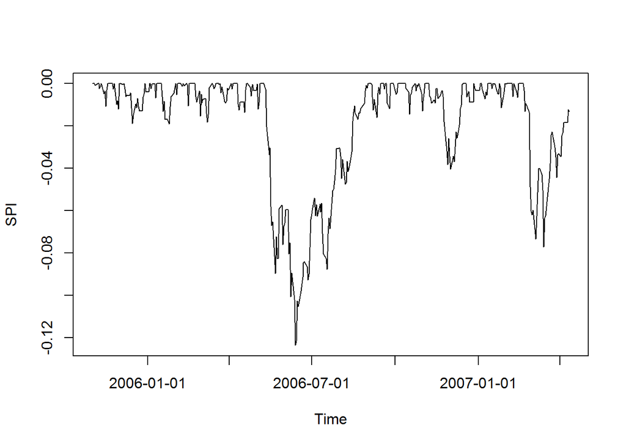

```r
## Plot Drawdowns -
dd = drawdowns(LPP2005REC[, "SPI"], main = "Drawdowns")
plot(dd)
```

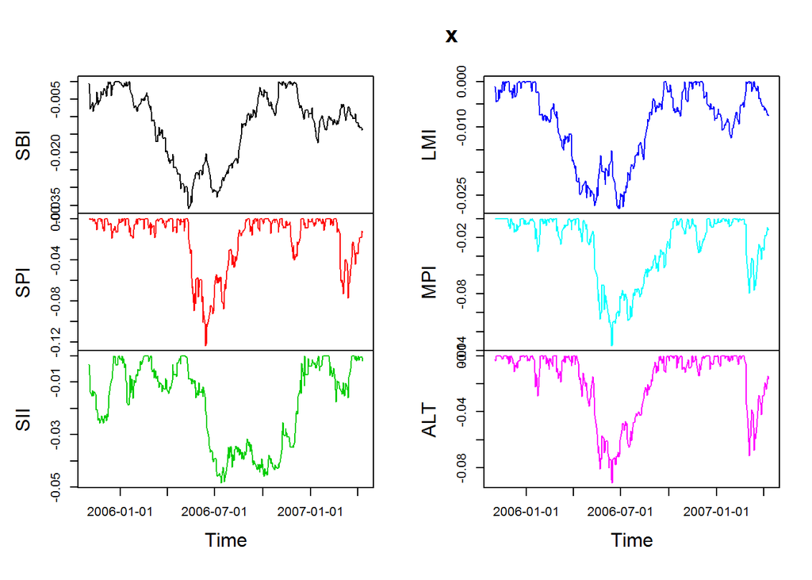

```r
dd = drawdowns(LPP2005REC[, 1:6], main = "Drawdowns")
plot(dd)
```

```r
## Compute Drawdowns Statistics -
ddStats <- drawdownsStats(SPI)
class(ddStats)
```

```
## [1] "data.frame"
```

```r
ddStats
```

```
##          From     Trough         To        Depth Length ToTrough Recovery
## 1  2006-05-10 2006-06-13 2006-09-01 -0.123592536     83       25       58
## 2  2007-02-20 2007-03-14 2007-04-11 -0.077123772     38       17       NA
## 3  2006-11-08 2006-12-01 2006-12-15 -0.040422201     28       18       10
## 4  2006-01-17 2006-01-25 2006-02-01 -0.019023057     12        7        5
## 5  2005-12-07 2005-12-15 2005-12-29 -0.018775316     17        7       10
## 6  2006-02-23 2006-03-08 2006-03-13 -0.018154802     13       10        3
## 7  2006-09-05 2006-09-11 2006-09-15 -0.015983414      9        5        4
## 8  2006-10-13 2006-10-17 2006-10-23 -0.014355088      7        3        4
## 9  2006-04-11 2006-04-18 2006-04-20 -0.013634341      8        6        2
## 10 2006-10-30 2006-10-31 2006-11-03 -0.012989432      5        2        3
## 11 2006-04-24 2006-05-03 2006-05-05 -0.012015385     10        8        2
## 12 2005-11-28 2005-11-30 2005-12-01 -0.011953779      4        3        1
## 13 2006-09-22 2006-09-25 2006-09-26 -0.011881605      3        2        1
## 14 2007-01-25 2007-01-26 2007-01-30 -0.011309666      4        2        2
```

[output cut: 27 more lines]

```r
## Note, Only Univariate Series are allowd -
ddStats <- try(drawdownsStats(LPP2005REC))
class(ddStats)
```

```
## [1] "try-error"
```

### Fifteenth Example

```r
library("timeSeries", lib.loc="~/R/win-library/3.2")
## Compute Durations in days for the MSFT Sereries -
head(durations(MSFT, units = "days"))
```

```
## GMT
##            Duration
## 2000-09-27       NA
## 2000-09-28        1
## 2000-09-29        1
## 2000-10-02        3
## 2000-10-03        1
## 2000-10-04        1
```

```r
head(durations(MSFT, trim = TRUE, units = "days"))
```

```
## GMT
##            Duration
## 2000-09-28        1
## 2000-09-29        1
## 2000-10-02        3
## 2000-10-03        1
## 2000-10-04        1
## 2000-10-05        1
```

```r
## The same in hours -
head(durations(MSFT, trim = TRUE, units = "hours"))
```

```
## GMT
##            Duration
## 2000-09-28       24
## 2000-09-29       24
## 2000-10-02       72
## 2000-10-03       24
## 2000-10-04       24
## 2000-10-05       24
```

### Linear filtering Example

```r
library("timeSeries", lib.loc="~/R/win-library/3.2")
## Creata a Dummy Signal 'timeSeries' -
data <- matrix(rnorm(100), ncol = 2)
s <- timeSeries(data, units=c("A", "B"))
head(s)
```

```
##
##               A           B
## [1,]  0.6049403  0.19180198
## [2,]  0.1772970 -0.46935000
## [3,] -0.2874205  0.01894512
## [4,]  0.4380198 -0.29674124
## [5,]  0.7361928  0.04837226
## [6,]  0.8548828 -0.35531105
```

```r
## Filter the series -
f <- filter(s, rep(1, 3))
head(f)
```

```
##
##               A           B
## [1,]         NA          NA
## [2,]  0.4948168 -0.25860289
## [3,]  0.3278963 -0.74714611
## [4,]  0.8867921 -0.22942386
## [5,]  2.0290954 -0.60368003
## [6,] -1.1545754  0.08068904
```

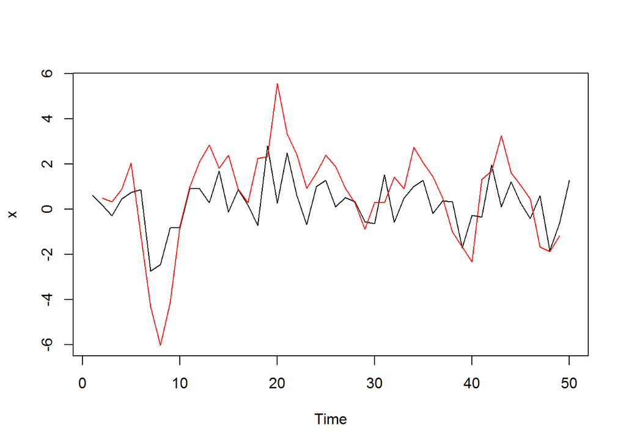

```r
## Plot and Compare the first series -
plot(cbind(s[, 1], f[, 1]), plot.type="s")
```

###Financial Center Example

```r
library("timeSeries", lib.loc="~/R/win-library/3.2")
## An artificial timeSeries Object -
tS <- dummySeries()
tS
```

```
## GMT
##                  TS.1       TS.2
## 2016-01-01 0.85224036 0.74274595
## 2016-02-01 0.26593879 0.35120383
## 2016-03-01 0.03341333 0.44849813
## 2016-04-01 0.48363104 0.43281575
## 2016-05-01 0.72464649 0.56294098
## 2016-06-01 0.47083477 0.07404873
## 2016-07-01 0.02187875 0.61893963
## 2016-08-01 0.50368645 0.68965039
## 2016-09-01 0.22949904 0.70085961
## 2016-10-01 0.41140940 0.14205515
## 2016-11-01 0.28290997 0.45645748
## 2016-12-01 0.53577216 0.93127636
```

```r
## Print Financial Center -
finCenter(tS)
```

```
## [1] "GMT"
```

```r
getFinCenter(tS)
```

```
## [1] "GMT"
```

```r
## Assign New Financial Center -
finCenter(tS) <- "Zurich"
tS
```

```
## Zurich
##                           TS.1       TS.2
## 2016-01-01 01:00:00 0.85224036 0.74274595
## 2016-02-01 01:00:00 0.26593879 0.35120383
## 2016-03-01 01:00:00 0.03341333 0.44849813
## 2016-04-01 02:00:00 0.48363104 0.43281575
## 2016-05-01 02:00:00 0.72464649 0.56294098
## 2016-06-01 02:00:00 0.47083477 0.07404873
## 2016-07-01 02:00:00 0.02187875 0.61893963
## 2016-08-01 02:00:00 0.50368645 0.68965039
## 2016-09-01 02:00:00 0.22949904 0.70085961
## 2016-10-01 02:00:00 0.41140940 0.14205515
## 2016-11-01 01:00:00 0.28290997 0.45645748
## 2016-12-01 01:00:00 0.53577216 0.93127636
```

```r
setFinCenter(tS) <- "New_York"
tS
```

```
## New_York
##                           TS.1       TS.2
## 2015-12-31 19:00:00 0.85224036 0.74274595
## 2016-01-31 19:00:00 0.26593879 0.35120383
## 2016-02-29 19:00:00 0.03341333 0.44849813
## 2016-03-31 20:00:00 0.48363104 0.43281575
## 2016-04-30 20:00:00 0.72464649 0.56294098
## 2016-05-31 20:00:00 0.47083477 0.07404873
## 2016-06-30 20:00:00 0.02187875 0.61893963
## 2016-07-31 20:00:00 0.50368645 0.68965039
## 2016-08-31 20:00:00 0.22949904 0.70085961
## 2016-09-30 20:00:00 0.41140940 0.14205515
## 2016-10-31 20:00:00 0.28290997 0.45645748
## 2016-11-30 19:00:00 0.53577216 0.93127636
```

### timeSeries Class, Coercion and Transformation Example

```r
library("timeSeries", lib.loc="~/R/win-library/3.2")
## Create an Artificial timeSeries Object -
setRmetricsOptions(myFinCenter = "GMT")
charvec <- timeCalendar()
data <- matrix(rnorm(12))
TS <- timeSeries(data, charvec, units = "RAND")
TS
```

```
## GMT
##                   RAND
## 2016-01-01 -0.10587971
## 2016-02-01  0.34928815
## 2016-03-01 -0.11433440
## 2016-04-01 -0.55758615
## 2016-05-01 -1.99106150
## 2016-06-01  0.93550097
## 2016-07-01  0.06809019
## 2016-08-01  0.85343882
## 2016-09-01 -0.25332415
## 2016-10-01  0.64356666
## 2016-11-01 -1.30023833
## 2016-12-01  0.58119776
```

```r
## Test for timeSeries -
is.timeSeries(TS)
```

```
## [1] TRUE
```

### CChecks if a Time Series is Univariate Example

```r
library("timeSeries", lib.loc="~/R/win-library/3.2")
## Load Microsoft Data -
setRmetricsOptions(myFinCenter = "GMT")
data(MSFT)
Open = MSFT[, "Open"]
## Is the timeSeries Univariate -
isUnivariate(MSFT)
```

```
## [1] FALSE
```

```r
isUnivariate(Open)
```

```
## [1] TRUE
```

```r
## Is the timeSeries Multivariate -
isMultivariate(MSFT)
```

```
## [1] TRUE
```

```r
isMultivariate(Open)
```

```
## [1] FALSE
```

### Mathematical Time Series Operations Example

```r
library("timeSeries", lib.loc="~/R/win-library/3.2")
## Create an Artificial timeSeries Object -
setRmetricsOptions(myFinCenter = "GMT")
charvec = timeCalendar()
set.seed(4711)
data = matrix(exp(cumsum(rnorm(12, sd = 0.1))))
TS = timeSeries(data, charvec, units = "TS")
TS
```

```
## GMT
##                   TS
## 2016-01-01 1.1995824
## 2016-02-01 1.3757753
## 2016-03-01 1.5506114
## 2016-04-01 1.4887865
## 2016-05-01 1.4005479
## 2016-06-01 1.2043889
## 2016-07-01 1.3069906
## 2016-08-01 1.1867998
## 2016-09-01 1.1815277
## 2016-10-01 1.2389245
## 2016-11-01 1.1230263
## 2016-12-01 0.9596526
```

```r
## Mathematical Operations: | +/- * ^ ... -
TS^2
```

```
## GMT
##                  TS
## 2016-01-01 1.438998
## 2016-02-01 1.892758
## 2016-03-01 2.404396
## 2016-04-01 2.216485
## 2016-05-01 1.961534
## 2016-06-01 1.450553
## 2016-07-01 1.708224
## 2016-08-01 1.408494
## 2016-09-01 1.396008
## 2016-10-01 1.534934
## 2016-11-01 1.261188
## 2016-12-01 0.920933
```

```r
TS[2:4]
```

```
## [1] 1.375775 1.550611 1.488787
```

```r
OR = returns(TS)
OR
```

```
## GMT
##                      TS
## 2016-02-01  0.137043950
## 2016-03-01  0.119631824
## 2016-04-01 -0.040687920
## 2016-05-01 -0.061097880
## 2016-06-01 -0.150891205
## 2016-07-01  0.081754941
## 2016-08-01 -0.096466789
## 2016-09-01 -0.004452208
## 2016-10-01  0.047435474
## 2016-11-01 -0.098216632
## 2016-12-01 -0.157211053
```

```r
OR > 0
```

```
## GMT
##               TS
## 2016-02-01  TRUE
## 2016-03-01  TRUE
## 2016-04-01 FALSE
## 2016-05-01 FALSE
## 2016-06-01 FALSE
## 2016-07-01  TRUE
## 2016-08-01 FALSE
## 2016-09-01 FALSE
## 2016-10-01  TRUE
## 2016-11-01 FALSE
## 2016-12-01 FALSE
```

### Lag a Time Series Example

```r
library("timeSeries", lib.loc="~/R/win-library/3.2")
## Load Micsrosoft Data Set -
x = MSFT[1:20, "Open"]
## Lag the timeSeries Object:
lag(x, k = -1:1)
```

```
## GMT
##            Open[-1] Open[0] Open[1]
## 2000-09-27  60.8125 63.4375      NA
## 2000-09-28  61.0000 60.8125 63.4375
## 2000-09-29  60.5000 61.0000 60.8125
## 2000-10-02  59.5625 60.5000 61.0000
## 2000-10-03  56.3750 59.5625 60.5000
## 2000-10-04  55.5000 56.3750 59.5625
## 2000-10-05  55.8125 55.5000 56.3750
## 2000-10-06  55.6250 55.8125 55.5000
## 2000-10-09  53.9375 55.6250 55.8125
## 2000-10-10  54.0000 53.9375 55.6250
## 2000-10-11  56.3125 54.0000 53.9375
## 2000-10-12  53.8750 56.3125 54.0000
## 2000-10-13  53.5000 53.8750 56.3125
## 2000-10-16  51.8750 53.5000 53.8750
## 2000-10-17  49.6250 51.8750 53.5000
## 2000-10-18  58.4375 49.6250 51.8750
## 2000-10-19  61.3125 58.4375 49.6250
## 2000-10-20  64.6250 61.3125 58.4375
## 2000-10-23  62.6250 64.6250 61.3125
## 2000-10-24       NA 62.6250 64.6250
```

### Merges two ’timeSeries’ objects Example

```r
library("timeSeries", lib.loc="~/R/win-library/3.2")
## Load Series -
x <- MSFT[1:12, ]
## Merge 'timeSeries' with missing Object -
merge(x)
```

```
## GMT
##               Open    High     Low   Close   Volume
## 2000-09-27 63.4375 63.5625 59.8125 60.6250 53077800
## 2000-09-28 60.8125 61.8750 60.6250 61.3125 26180200
## 2000-09-29 61.0000 61.3125 58.6250 60.3125 37026800
## 2000-10-02 60.5000 60.8125 58.2500 59.1250 29281200
## 2000-10-03 59.5625 59.8125 56.5000 56.5625 42687000
## 2000-10-04 56.3750 56.5625 54.5000 55.4375 68226700
## 2000-10-05 55.5000 57.2500 55.2500 55.3750 40549700
## 2000-10-06 55.8125 56.7500 54.7500 55.5625 30897000
## 2000-10-09 55.6250 55.7500 53.0000 54.1875 29161800
## 2000-10-10 53.9375 55.5625 53.8125 54.5625 31033100
## 2000-10-11 54.0000 56.9375 54.0000 55.7500 50602900
## 2000-10-12 56.3125 56.8750 53.8125 54.3750 45109800
```

```r
## Merge 'timeSeries' with numeric Object -
y <- rnorm(12)
class(y)
```

```
## [1] "numeric"
```

```r
merge(x, y)
```

```
## GMT
##               Open    High     Low   Close   Volume           x
## 2000-09-27 63.4375 63.5625 59.8125 60.6250 53077800  0.03533135
## 2000-09-28 60.8125 61.8750 60.6250 61.3125 26180200  0.42314888
## 2000-09-29 61.0000 61.3125 58.6250 60.3125 37026800  0.20222884
## 2000-10-02 60.5000 60.8125 58.2500 59.1250 29281200  1.57620746
## 2000-10-03 59.5625 59.8125 56.5000 56.5625 42687000 -0.46904286
## 2000-10-04 56.3750 56.5625 54.5000 55.4375 68226700  0.37957991
## 2000-10-05 55.5000 57.2500 55.2500 55.3750 40549700 -0.53462554
## 2000-10-06 55.8125 56.7500 54.7500 55.5625 30897000  1.03171730
## 2000-10-09 55.6250 55.7500 53.0000 54.1875 29161800  0.70956662
## 2000-10-10 53.9375 55.5625 53.8125 54.5625 31033100  0.07844901
## 2000-10-11 54.0000 56.9375 54.0000 55.7500 50602900  0.97608044
## 2000-10-12 56.3125 56.8750 53.8125 54.3750 45109800 -0.26208703
```

```r
## Merge 'timeSeries' with matrix Object -
y <- matrix(rnorm(24), ncol=2)
class(y)
```

```
## [1] "matrix"
```

```r
merge(x, y)
```

```
## GMT
##               Open    High     Low   Close   Volume        y.1
## 2000-09-27 63.4375 63.5625 59.8125 60.6250 53077800 -1.3702965
## 2000-09-28 60.8125 61.8750 60.6250 61.3125 26180200  0.1962448
## 2000-09-29 61.0000 61.3125 58.6250 60.3125 37026800 -1.2123556
## 2000-10-02 60.5000 60.8125 58.2500 59.1250 29281200 -0.1588557
## 2000-10-03 59.5625 59.8125 56.5000 56.5625 42687000 -0.6683035
## 2000-10-04 56.3750 56.5625 54.5000 55.4375 68226700  0.8826032
## 2000-10-05 55.5000 57.2500 55.2500 55.3750 40549700  0.2182945
## 2000-10-06 55.8125 56.7500 54.7500 55.5625 30897000  1.7655480
## 2000-10-09 55.6250 55.7500 53.0000 54.1875 29161800  1.1424191
## 2000-10-10 53.9375 55.5625 53.8125 54.5625 31033100 -0.5911973
## 2000-10-11 54.0000 56.9375 54.0000 55.7500 50602900 -0.6178305
## 2000-10-12 56.3125 56.8750 53.8125 54.3750 45109800 -0.7610169
##                     y.2
## 2000-09-27 -0.287532357
## 2000-09-28 -2.559374272
## 2000-09-29 -1.839761220
## 2000-10-02  1.672603722
## 2000-10-03 -1.272653368
## 2000-10-04  0.001369812
## 2000-10-05 -0.231584632
## 2000-10-06 -1.947726847
## 2000-10-09  0.602454282
## 2000-10-10  0.742540487
## 2000-10-11  0.234180532
## 2000-10-12  1.949510250
```

```r
## Merge 'timeSeries' with matrix Object -
y <- timeSeries(data=rnorm(12), charvec=time(x))
class(y)
```

```
## [1] "timeSeries"
## attr(,"package")
## [1] "timeSeries"
```

```r
merge(x, y)
```

```
## GMT
##               Open    High     Low   Close   Volume       TS.1
## 2000-09-27 63.4375 63.5625 59.8125 60.6250 53077800  0.8198556
## 2000-09-28 60.8125 61.8750 60.6250 61.3125 26180200 -1.7209253
## 2000-09-29 61.0000 61.3125 58.6250 60.3125 37026800 -0.3384896
## 2000-10-02 60.5000 60.8125 58.2500 59.1250 29281200  0.5384583
## 2000-10-03 59.5625 59.8125 56.5000 56.5625 42687000 -0.4676473
## 2000-10-04 56.3750 56.5625 54.5000 55.4375 68226700 -1.4978528
## 2000-10-05 55.5000 57.2500 55.2500 55.3750 40549700 -0.5362298
## 2000-10-06 55.8125 56.7500 54.7500 55.5625 30897000 -0.9078017
## 2000-10-09 55.6250 55.7500 53.0000 54.1875 29161800 -0.3170325
## 2000-10-10 53.9375 55.5625 53.8125 54.5625 31033100 -2.0012587
## 2000-10-11 54.0000 56.9375 54.0000 55.7500 50602900  0.7270278
## 2000-10-12 56.3125 56.8750 53.8125 54.3750 45109800  0.9402249
```

### Model Frames for Time Series Objects Example

```r
library("timeSeries", lib.loc="~/R/win-library/3.2")
## Load Microsoft Data -
setRmetricsOptions(myFinCenter = "GMT")
X <- MSFT[1:12, ]
## Extract High's and Low's:
DATA <- model.frame( ~ High + Low, data = X)
class(DATA)
```

```
## [1] "data.frame"
```

```r
as.timeSeries(DATA)
```

```
## GMT
##               High     Low
## 2000-09-27 63.5625 59.8125
## 2000-09-28 61.8750 60.6250
## 2000-09-29 61.3125 58.6250
## 2000-10-02 60.8125 58.2500
## 2000-10-03 59.8125 56.5000
## 2000-10-04 56.5625 54.5000
## 2000-10-05 57.2500 55.2500
## 2000-10-06 56.7500 54.7500
## 2000-10-09 55.7500 53.0000
## 2000-10-10 55.5625 53.8125
## 2000-10-11 56.9375 54.0000
## 2000-10-12 56.8750 53.8125
```

```r
## Extract Open Prices and their log10's:
base <- 10
Open <- model.frame(Open ~ log(Open, base = `base`), data = X)
colnames(Open) <- c("X", "log10(X)")
class(Open)
```

```
## [1] "data.frame"
```

```r
as.timeSeries(Open)
```

```
## GMT
##                  X log10(X)
## 2000-09-27 63.4375 1.802346
## 2000-09-28 60.8125 1.783993
## 2000-09-29 61.0000 1.785330
## 2000-10-02 60.5000 1.781755
## 2000-10-03 59.5625 1.774973
## 2000-10-04 56.3750 1.751087
## 2000-10-05 55.5000 1.744293
## 2000-10-06 55.8125 1.746731
## 2000-10-09 55.6250 1.745270
## 2000-10-10 53.9375 1.731891
## 2000-10-11 54.0000 1.732394
## 2000-10-12 56.3125 1.750605
```

### Plot a time-serie Example

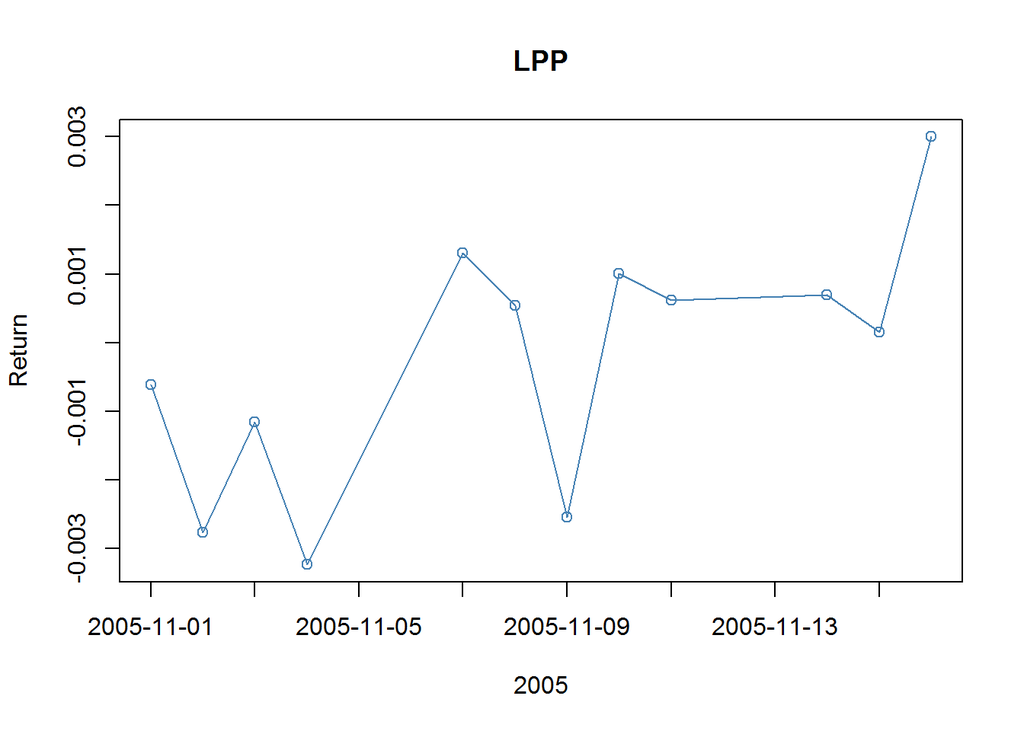

```r
library("timeSeries", lib.loc="~/R/win-library/3.2")
## Load Swiss Pension Fund Benchmark Data -
LPP <- LPP2005REC[1:12, 1:4]
colnames(LPP) <- abbreviate(colnames(LPP), 2)
finCenter(LPP) <- "GMT"
## Example Plot 1 -
plot(LPP[, 1], type = "o", col = "steelblue",
main = "LPP", xlab = "2005", ylab = "Return")
```

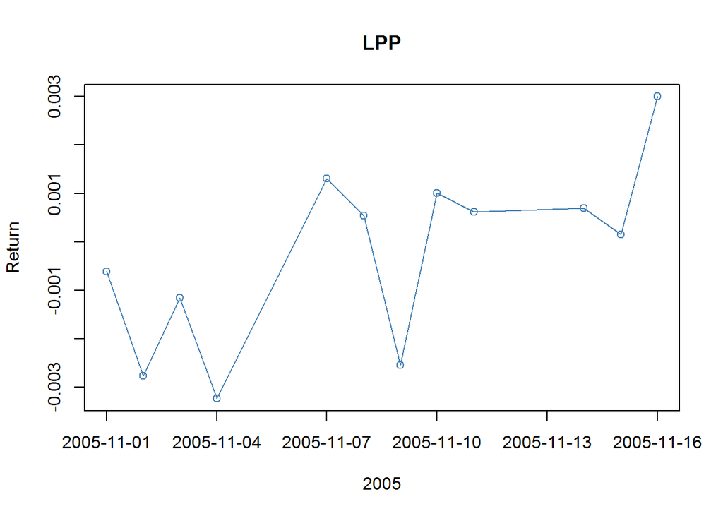

```r
plot(LPP[, 1], at="auto", type = "o", col = "steelblue",
main = "LPP", xlab = "2005", ylab = "Return")
```

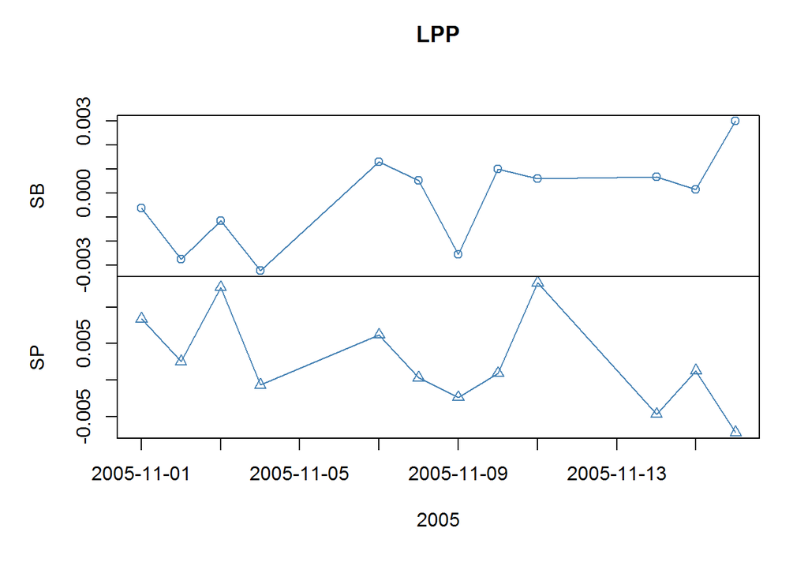

```r
## Example Plot 2 -
plot(LPP[, 1:2], type = "o", col = "steelblue",
main = "LPP", xlab = "2005", ylab = "Return")
```

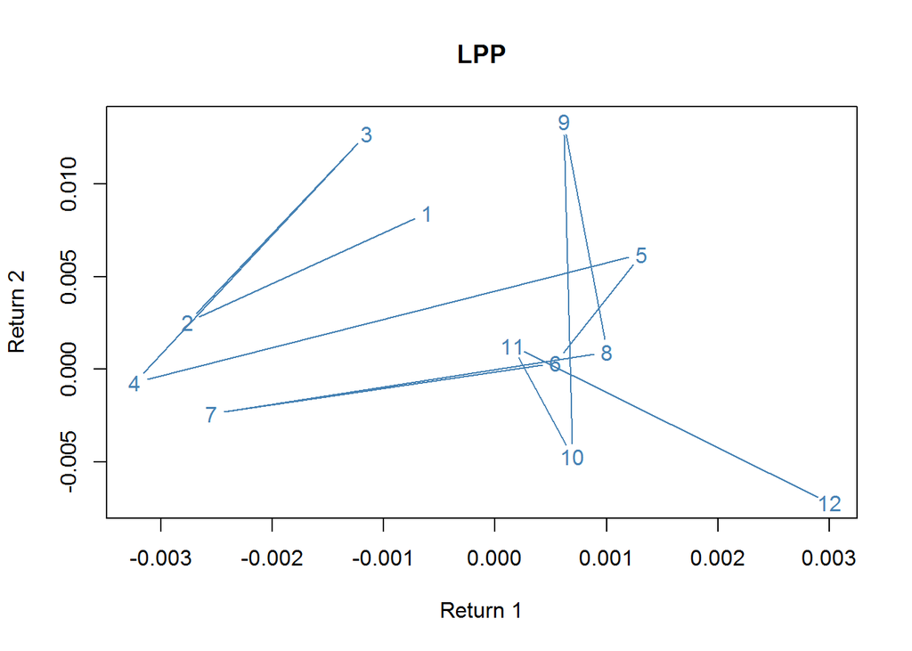

```r
## Example Plot 3 -
plot(LPP[, 1], LPP[, 2], type = "p", col = "steelblue",
main = "LPP", xlab = "Return 1", ylab = "Return 2")
```

```r
## Example Plot 4a, The Wrong Way to do it! -
LPP <- as.timeSeries(data(LPP2005REC))
ZRH <- as.timeSeries(LPP[,"SPI"], zone = "Zurich", FinCenter = "Zurich")
NYC <- as.timeSeries(LPP[,"LMI"], zone = "NewYork", FinCenter = "NewYork")
finCenter(ZRH)
```

```
## [1] "Zurich"
```

```r
finCenter(NYC)
```

```
## [1] "NewYork"
```

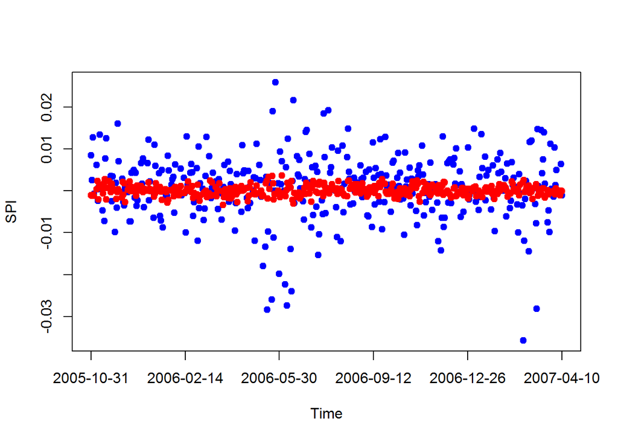

```r
plot(ZRH, at="auto", type = "p", pch = 19, col = "blue")
points(NYC, pch = 19, col = "red")
```

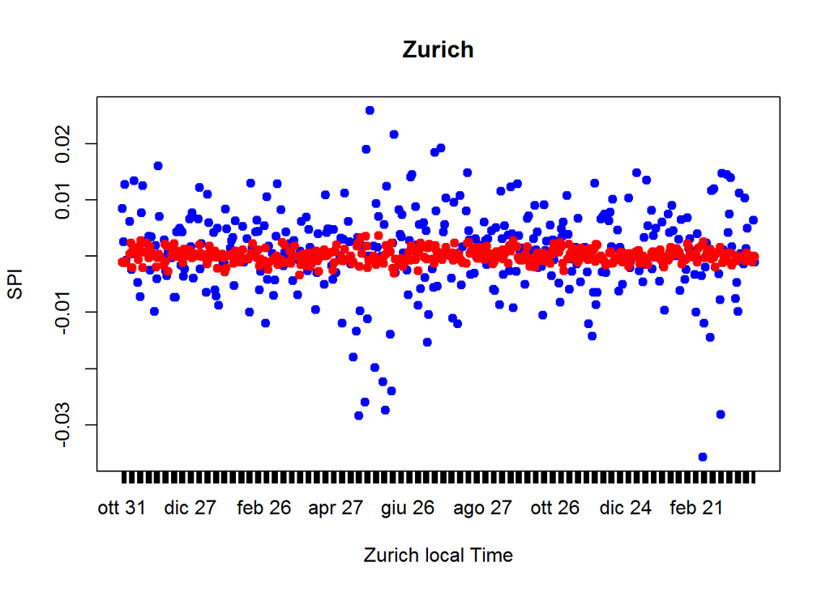

```r
## Example Plot 4b, Convert NYC to Zurich Time -
finCenter(ZRH) <- "Zurich"
finCenter(NYC) <- "Zurich"
at <- unique(round(time(ZRH)))
plot(ZRH, type = "p", pch = 19, col = "blue", format = "%b %d", at = at,
xlab = paste(ZRH@FinCenter, "local Time"), main = ZRH@FinCenter)
points(NYC, pch = 19, col = "red")
```

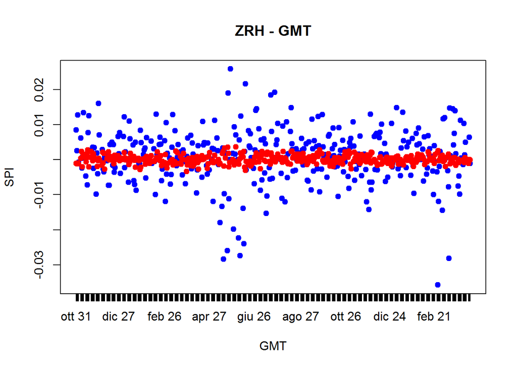

```r
## Example 4c, Force Everything to GMT Using "FinCenter" Argument -
finCenter(ZRH) <- "Zurich"
finCenter(NYC) <- "NewYork"
at <- unique(round(time(ZRH)))
plot(ZRH, type = "p", pch = 19, col = "blue", format = "%b %d", at = at,
FinCenter = "GMT", xlab = "GMT", main = "ZRH - GMT")
points(NYC, FinCenter = "GMT", pch = 19, col = "red")
```

###Print a Time Series Example

```r
library("timeSeries", lib.loc="~/R/win-library/3.2")
## Load Micsrosoft Data -
setRmetricsOptions(myFinCenter = "GMT")
LPP <- MSFT[1:12, 1:4]
## Abbreviate Column Names -
colnames(LPP) <- abbreviate(colnames(LPP), 6)
## Print Data Set -
print(LPP)
```

```
## GMT
##               Open    High     Low   Close
## 2000-09-27 63.4375 63.5625 59.8125 60.6250
## 2000-09-28 60.8125 61.8750 60.6250 61.3125
## 2000-09-29 61.0000 61.3125 58.6250 60.3125
## 2000-10-02 60.5000 60.8125 58.2500 59.1250
## 2000-10-03 59.5625 59.8125 56.5000 56.5625
## 2000-10-04 56.3750 56.5625 54.5000 55.4375
## 2000-10-05 55.5000 57.2500 55.2500 55.3750
## 2000-10-06 55.8125 56.7500 54.7500 55.5625
## 2000-10-09 55.6250 55.7500 53.0000 54.1875
## 2000-10-10 53.9375 55.5625 53.8125 54.5625
## 2000-10-11 54.0000 56.9375 54.0000 55.7500
## 2000-10-12 56.3125 56.8750 53.8125 54.3750
```

```r
## Alternative Use, Show Data Set -
show(LPP)
```

```
## GMT
##               Open    High     Low   Close
## 2000-09-27 63.4375 63.5625 59.8125 60.6250
## 2000-09-28 60.8125 61.8750 60.6250 61.3125
## 2000-09-29 61.0000 61.3125 58.6250 60.3125
## 2000-10-02 60.5000 60.8125 58.2500 59.1250
## 2000-10-03 59.5625 59.8125 56.5000 56.5625
## 2000-10-04 56.3750 56.5625 54.5000 55.4375
## 2000-10-05 55.5000 57.2500 55.2500 55.3750
## 2000-10-06 55.8125 56.7500 54.7500 55.5625
## 2000-10-09 55.6250 55.7500 53.0000 54.1875
## 2000-10-10 53.9375 55.5625 53.8125 54.5625
## 2000-10-11 54.0000 56.9375 54.0000 55.7500
## 2000-10-12 56.3125 56.8750 53.8125 54.3750
```

### Sample Ranks of a Time Series Example

```r
library("timeSeries", lib.loc="~/R/win-library/3.2")
## Load Microsoft Data -
X <- 100 * returns(MSFT)
## Compute the Ranks -
head(rank(X[, "Open"]), 10)
```

```
## GMT
##            TS.1
## 2000-09-28   18
## 2000-09-29  138
## 2000-10-02  107
## 2000-10-03   87
## 2000-10-04    8
## 2000-10-05   86
## 2000-10-06  147
## 2000-10-09  122
## 2000-10-10   44
## 2000-10-11  132
```

```r
## Only Interested in the Vector, then use -
head(rank(series(X[, "Open"])), 10)
```

```
##  [1]  18 138 107  87   8  86 147 122  44 132
```

### Rolling Statistics Example

```r
library("timeSeries", lib.loc="~/R/win-library/3.2")
## Use Swiss Pension Fund Data Set of Returns -
head(LPP2005REC)
```

```
## GMT
##                     SBI          SPI          SII          LMI         MPI
## 2005-11-01 -0.000612745  0.008414595 -0.003190926 -0.001108882 0.001548062
## 2005-11-02 -0.002762009  0.002519342 -0.004117638 -0.001175939 0.000342876
## 2005-11-03 -0.001153092  0.012707292 -0.005209409 -0.000992456 0.010502959
## 2005-11-04 -0.003235750 -0.000702757 -0.001127165 -0.001198528 0.011679558
## 2005-11-07  0.001310970  0.006205226 -0.001795839  0.000360366 0.002709618
## 2005-11-08  0.000539312  0.000329260  0.002103374  0.002327040 0.000346843
##                     ALT        LPP25        LPP40        LPP60
## 2005-11-01 -0.002572971 -0.000130008  0.000199980  0.000809672
## 2005-11-02 -0.001141604 -0.001561421 -0.001120404 -0.000469730
## 2005-11-03  0.005007442  0.001541418  0.003317548  0.005731589
## 2005-11-04  0.009482677  0.000439969  0.002421248  0.004838735
## 2005-11-07  0.004723952  0.001638182  0.002246611  0.003012363
## 2005-11-08  0.000853619  0.001087309  0.000962708  0.000828043
```

```r
SPI <- LPP2005REC[, "SPI"]
head(SPI)
```

```
## GMT
##                     SPI
## 2005-11-01  0.008414595
## 2005-11-02  0.002519342
## 2005-11-03  0.012707292
## 2005-11-04 -0.000702757
## 2005-11-07  0.006205226
## 2005-11-08  0.000329260
```

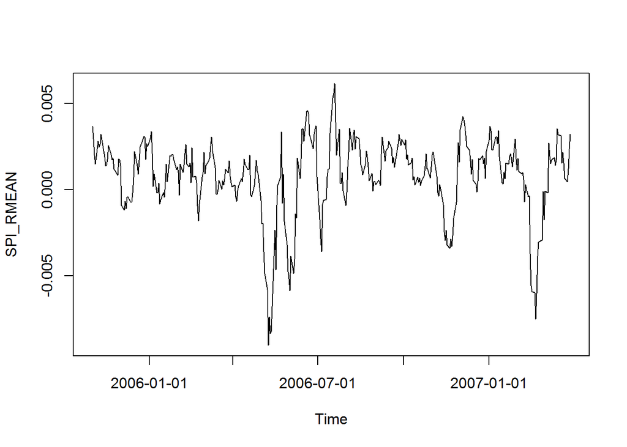

```r
## Plot Drawdowns -
rmean <- rollMean(SPI, k = 10)
plot(rmean)
```

###Cumulated Column Statistics Example

```r
library("timeSeries", lib.loc="~/R/win-library/3.2")
## Simulated Monthly Return Data -
X = matrix(rnorm(24), ncol = 2)
## Compute cumulated Sums -
rowCumsums(X)
```

```
##               [,1]       [,2]
##  [1,]  0.508673317  1.2724446
##  [2,]  0.792654229  0.9588602
##  [3,]  0.143154934  0.2254238
##  [4,] -0.022807823  1.0823259
##  [5,] -0.049878707  0.3613705
##  [6,] -0.927529120  1.4654705
##  [7,] -0.603169176  1.3229077
##  [8,] -0.773346887 -0.7833978
##  [9,]  0.961407735  0.7313792
## [10,] -0.001666551 -0.3575483
## [11,] -0.227480201  0.3305699
## [12,]  0.193355496  1.2792040
```

### Get and Set Data of a ’timeSeries’ Example

```r
library("timeSeries", lib.loc="~/R/win-library/3.2")
## A Dummy timeSeries Object
ts <- timeSeries()
ts
```

```
##
##      SS.1
## [1,]   NA
```

```r
## Get the Matrix Part -
mat <- series(ts)
class(mat)
```

```
## [1] "matrix"
```

```r
mat
```

```
##      SS.1
## [1,]   NA
```

```r
## Assign a New Univariate Series -
series(ts) <- rnorm(12)
ts
```

```
##
##             SS.1
##  [1,]  0.4765028
##  [2,] -2.0469177
##  [3,]  0.3240641
##  [4,]  0.2558027
##  [5,]  0.5432705
##  [6,] -1.0998279
##  [7,] -1.5648108
##  [8,] -0.1992681
##  [9,]  0.4800727
## [10,]  0.1802053
## [11,]  0.7788834
## [12,] -0.8608081
```

```r
## Assign a New Bivariate Series -
series(ts) <- rnorm(12)
ts
```

```
##
##              SS.1
##  [1,] -0.53406237
##  [2,] -0.42179909
##  [3,]  1.54286045
##  [4,] -0.61547070
##  [5,] -0.39077723
##  [6,]  0.39665330
##  [7,]  0.78156956
##  [8,] -0.01912605
##  [9,] -1.94431293
## [10,] -0.24550669
## [11,]  0.35202984
## [12,]  0.84190820
```

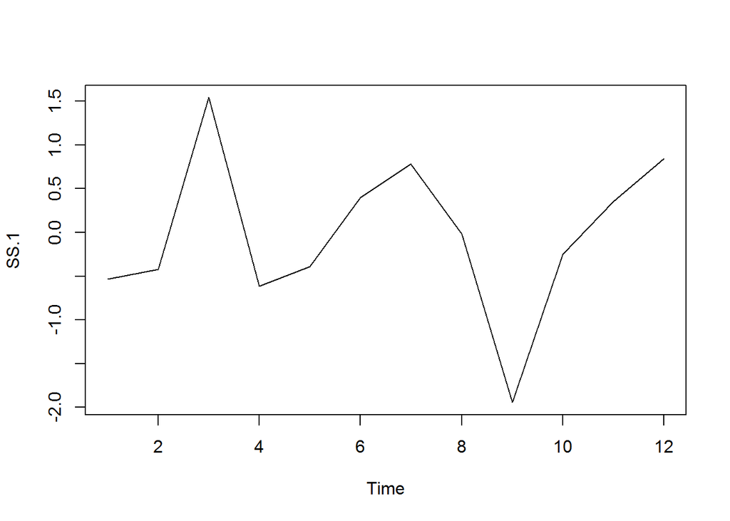

```r
plot(ts)
```

###extract window Example

```r
library("timeSeries", lib.loc="~/R/win-library/3.2")
## Load LPP Benchmark Returns -
x <- LPP2005REC[, 7:9]
range(time(x))
```

```
## GMT
## [1] [2005-11-01] [2007-04-11]
```

```r
## Extract Data for January 2006 -
window(x, "2006-01-01", "2006-01-31")
```

```
## GMT
##                   LPP25        LPP40        LPP60
## 2006-01-02  0.000165480  0.000297932  0.000444413
## 2006-01-03  0.000019500 -0.000076900  0.000009450
## 2006-01-04  0.001847585  0.002227044  0.002945121
## 2006-01-05 -0.000602521 -0.000805771 -0.001093968
## 2006-01-06  0.000553944  0.000844125  0.001291886
## 2006-01-09  0.001844267  0.003025315  0.004325551
## 2006-01-10 -0.001280919 -0.001540235 -0.001981789
## 2006-01-11  0.000960843  0.002094522  0.003631846
## 2006-01-12  0.002548068  0.003119294  0.003796029
## 2006-01-13 -0.001161811 -0.001200778 -0.001223253
## 2006-01-16  0.000193729  0.000162094  0.000196195
## 2006-01-17 -0.001337495 -0.002720934 -0.004437794
## 2006-01-18 -0.002019320 -0.004157731 -0.006873332
## 2006-01-19  0.001650710  0.003430897  0.005727921
## 2006-01-20 -0.002759185 -0.003613313 -0.004887407
## 2006-01-23 -0.002815600 -0.005072953 -0.007675798
## 2006-01-24  0.000253631  0.001224870  0.002318423
## 2006-01-25 -0.000604919  0.000462553  0.001621599
## 2006-01-26  0.001842887  0.003443139  0.005584311
## 2006-01-27  0.003394103  0.005791901  0.008762193
## 2006-01-30  0.001319517  0.002116907  0.003086897
## 2006-01-31  0.000222982  0.000133349  0.000055900
```

### More plotting Example

Taken from https://cran.r-project.org/web/packages/timeSeries/vignettes/timeSeriesPlot.pdf

```r
library("timeSeries", lib.loc="~/R/win-library/3.2")
library(PerformanceAnalytics)
require(timeSeries)
require(xts)
require(fTrading)
```

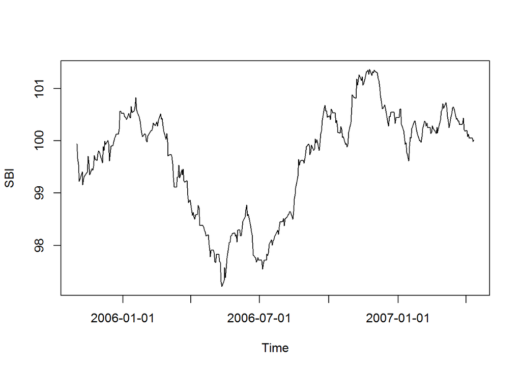

```r
tS1 <- 100 * cumulated(LPP2005REC[, 1]) # SBI (univariate)
tS2 <- 100 * cumulated(LPP2005REC[, 1:2]) # SBI & SPI (bivariate)
tS3 <- 100 * cumulated(LPP2005REC[, 1:3]) # SBI, SPI, SWIIT (Swiss Market)
tS6 <- 100 * cumulated(LPP2005REC[, 1:6]) # Swiss and Foreign Market Indexes

par(mfrow=c(1, 1))
plot(tS1)
```

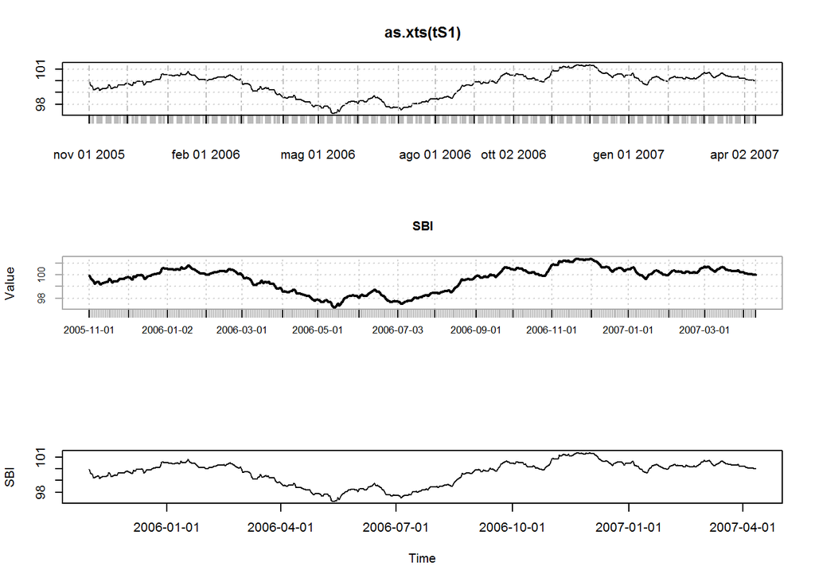

```r
par(mfrow=c(3, 1))
xts::plot.xts(as.xts(tS1))
PerformanceAnalytics::chart.TimeSeries(as.xts(tS1))
plot(tS1)
```

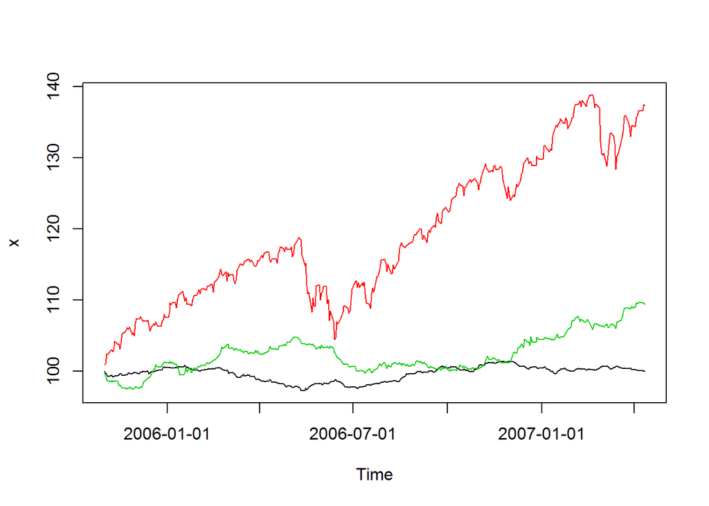

```r
par(mfrow=c(1, 1))
plot(tS3, plot.type="s")
```

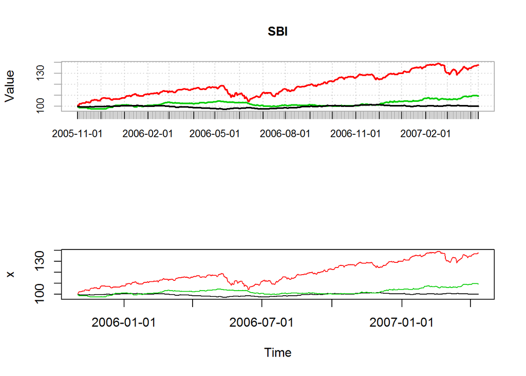

```r
par(mfrow=c(2, 1))
require(PerformanceAnalytics)
PerformanceAnalytics::chart.TimeSeries(as.xts(tS3))
plot(tS3, plot.type="s")
```

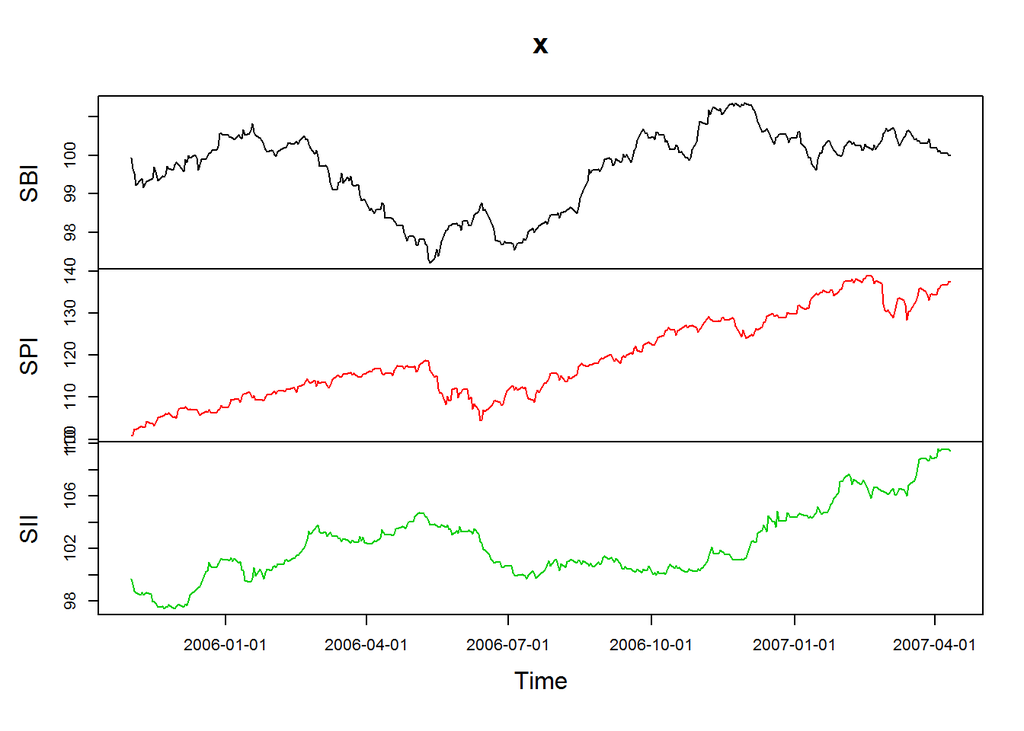

```r
par(mfrow=c(1, 1))
plot(tS3, plot.type="m")
```

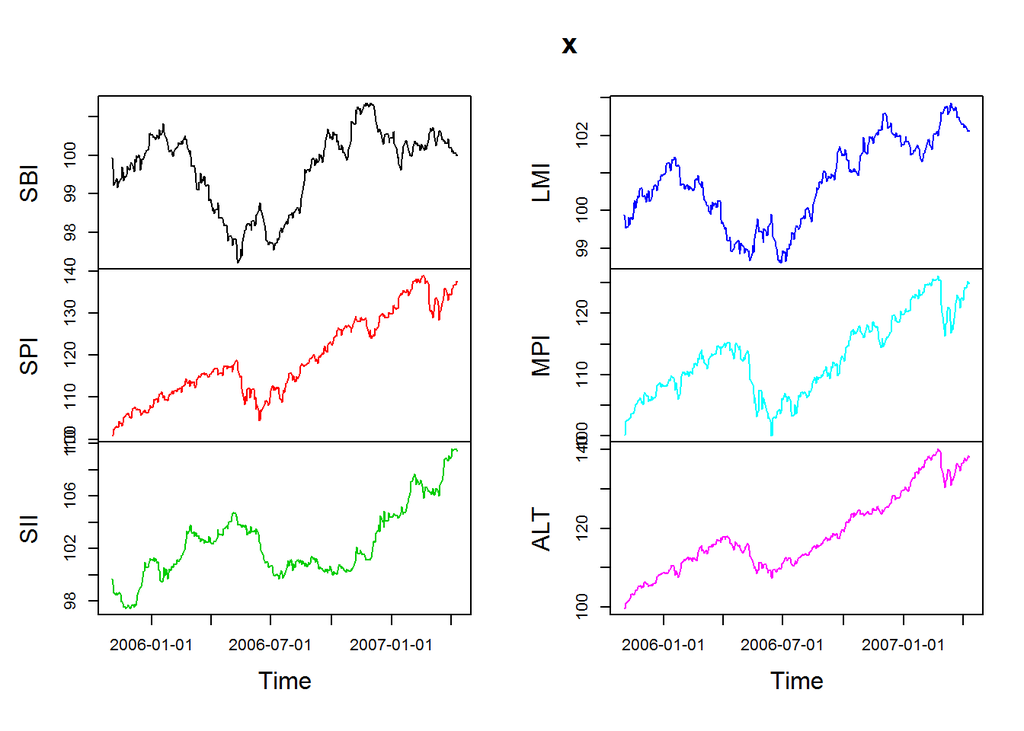

```r
par(mfrow=c(1, 1))
plot(tS6, plot.type="m")
```

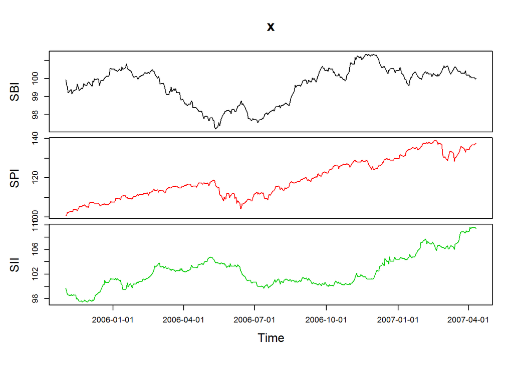

```r
par(mfrow=c(1, 1))
plot(tS3, plot.type="m", mar=c(gap=0.3, 5.1, gap=0.3, 2.1))
```

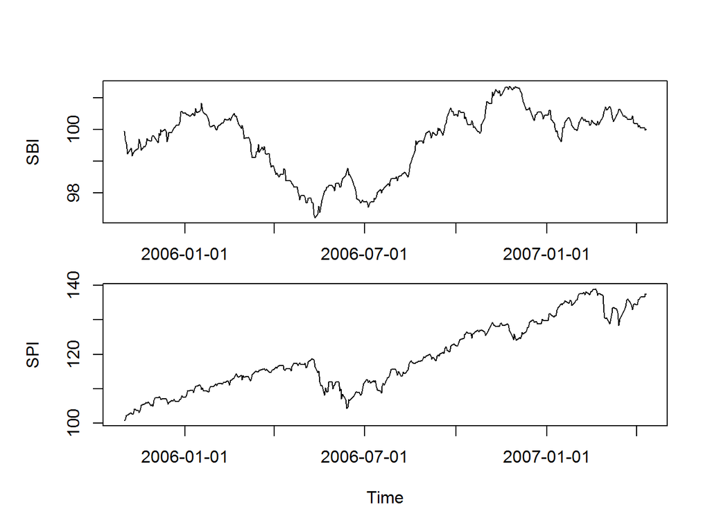

```r
par(mfrow=c(2, 1))
par(mar = c(bottom=1.5, 5.1, top=4, 2.1))
plot(tS2[, 1])
par(mar = c(bottom=4, 5.1, top=1.5, 2.1))
plot(tS2[, 2])
```

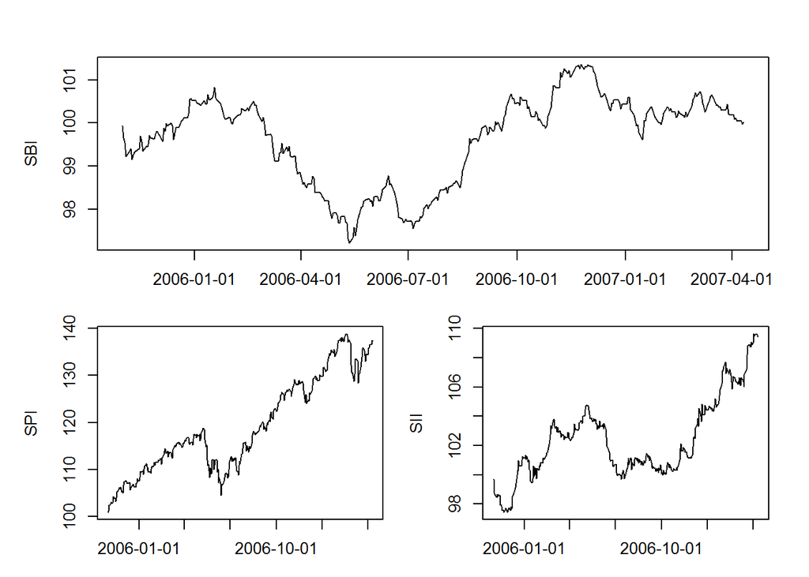

```r
nf <- layout(mat=matrix(c(1, 1, 2, 3), byrow = TRUE, nrow=2))
par(mar = c(bottom=2, 5.1, top=3, 2.1))
plot(tS3[, 1])
par(mar = c(bottom=3, 5.1, top=2, 1.1))
plot(tS3[, 2])
par(mar = c(bottom=3, 4.1, top=2, 2.1))
plot(tS3[, 3])
```

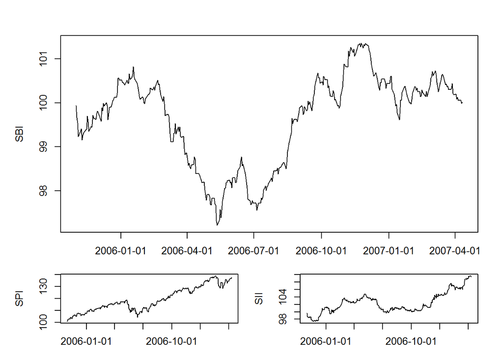

```r
nf <- layout(mat=matrix(c(1, 1, 2, 3), byrow=TRUE, nrow=2), heights=c(2.5,1))
par(mar = c(bottom=2, 5.1, top=3, 2.1))
plot(tS3[, 1])
par(mar = c(bottom=3, 5.1, top=1.5, 1.1))
plot(tS3[, 2])
par(mar = c(bottom=3, 4.1, top=1.5, 2.1))
plot(tS3[, 3])
```

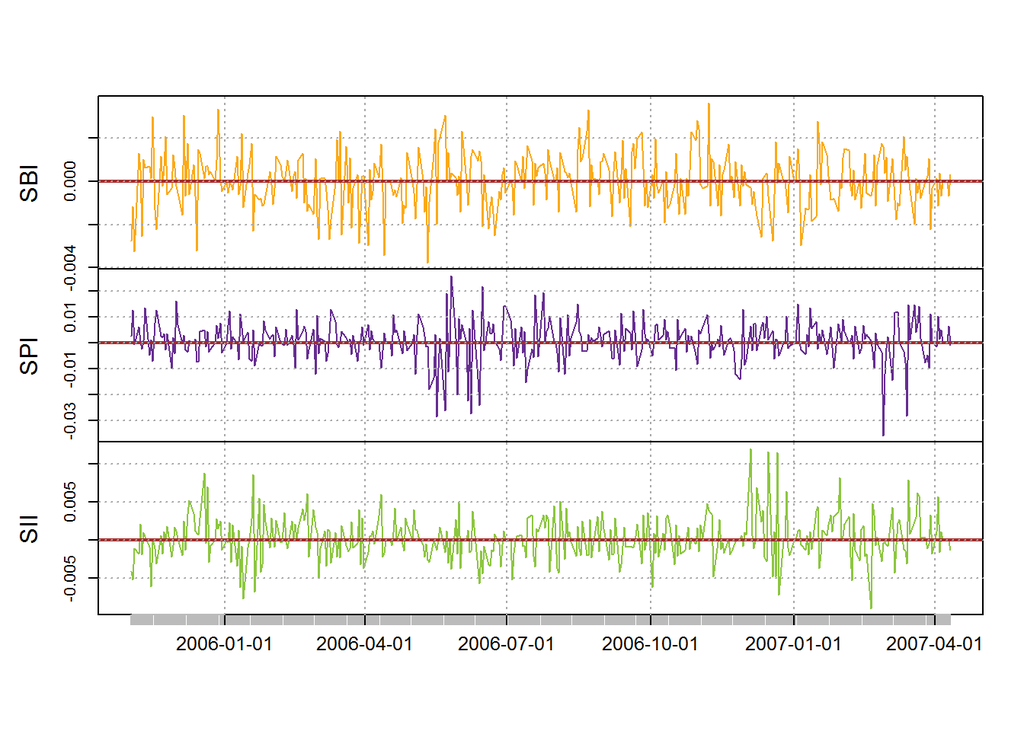

```r
par(mfrow=c(1, 1))
lines2 <- function(X, Y, type, xlab, ylab, col, pch, lty, lwd, cex) {lines(x=X, y=Y, col=col)+ abline(h=0, col = "brown", lwd=2)}
plot(returns(tS3), plot.type="m", col = .colorwheelPalette(3), panel=lines2, at="pretty")
```

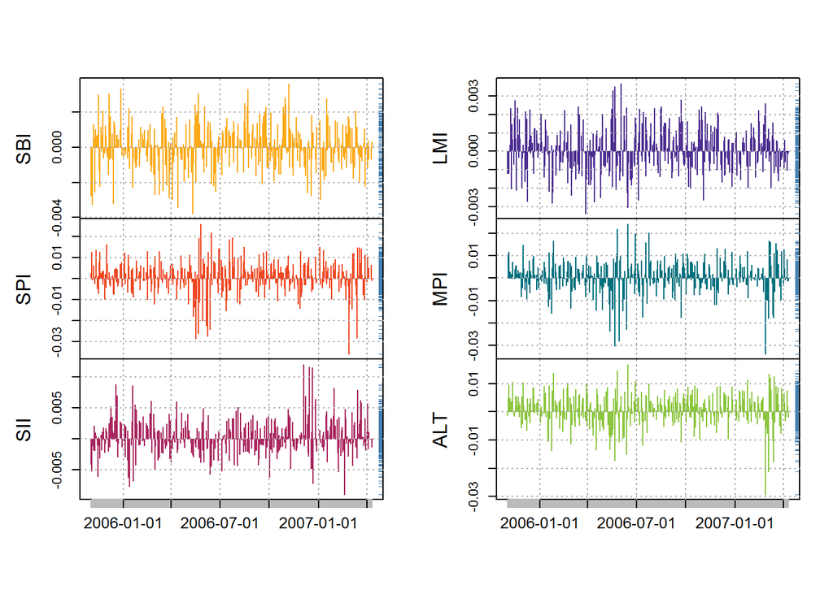

```r
par(mfrow=c(1, 1))
lines2 <- function(X, Y, type, xlab, ylab, col, pch, lty, lwd, cex) {lines(x=X, y=Y, type="h", col=col)+ rug(Y, side=4, col="steelblue") }
plot(returns(tS6), plot.type="m", col = .colorwheelPalette(6), panel=lines2, at="pretty")
```

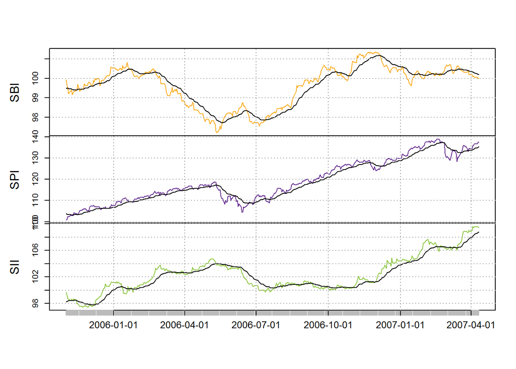

```r
library("fTrading")
par(mfrow=c(1, 1))
lines2 <- function(X, Y, type, xlab, ylab, col, pch, lty, lwd, cex) { lines(x=X, y=Y, type="l", col=col) +lines(x=X, y=emaTA(Y), col="black") }
plot(tS3, plot.type="m", col = .colorwheelPalette(3), panel=lines2, grid=TRUE, at="pretty")
```

## Markov chain

Taken from markov chain https://cran.rstudio.com/web/packages/markovchain/markovchain.pdf

```r
library("markovchain", lib.loc="~/R/win-library/3.2")
```

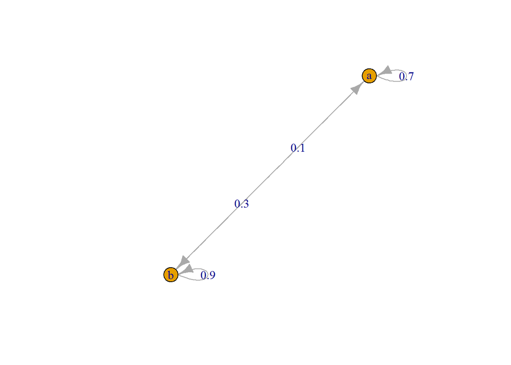

```r
#create some markov chains
statesNames=c("a","b")
mcA<-new("markovchain", transitionMatrix=matrix(c(0.7,0.3,0.1,0.9),byrow=TRUE,
nrow=2, dimnames=list(statesNames,statesNames)))
plot(mcA)
```

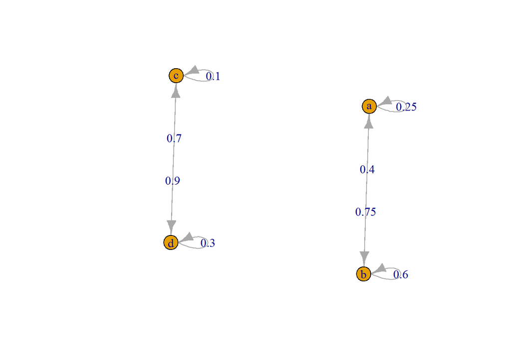

```r
statesNames=c("a","b","c")
mcB<-new("markovchain", states=statesNames, transitionMatrix=
matrix(c(0.2,0.5,0.3,
0,1,0,
0.1,0.8,0.1),nrow=3, byrow=TRUE, dimnames=list(statesNames,
statesNames)
))
statesNames=c("a","b","c","d")
matrice<-matrix(c(0.25,0.75,0,0,0.4,0.6,0,0,0,0,0.1,0.9,0,0,0.7,0.3),
nrow=4, byrow=TRUE)
mcC<-new("markovchain", states=statesNames, transitionMatrix=matrice)
plot(mcC)
```

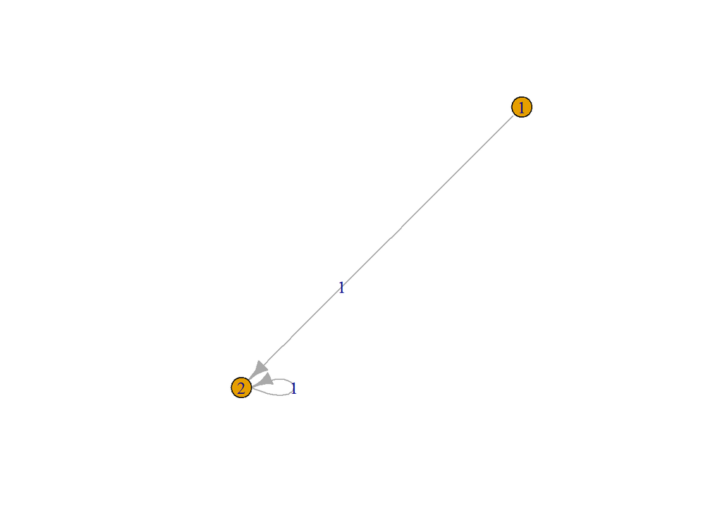

```r
mcD<-new("markovchain", transitionMatrix=matrix(c(0,1,0,1), nrow=2,byrow=TRUE))
plot(mcD)
```

```r
#operations with S4 methods
mcA^2
```

```
## Unnamed Markov chain^2
##  A  2 - dimensional discrete Markov Chain defined by the following states:
##  a, b
##  The transition matrix  (by rows)  is defined as follows:
##      a    b
## a 0.52 0.48
## b 0.16 0.84
```

```r
steadyStates(mcB)
```

```
##      a b c
## [1,] 0 1 0
```

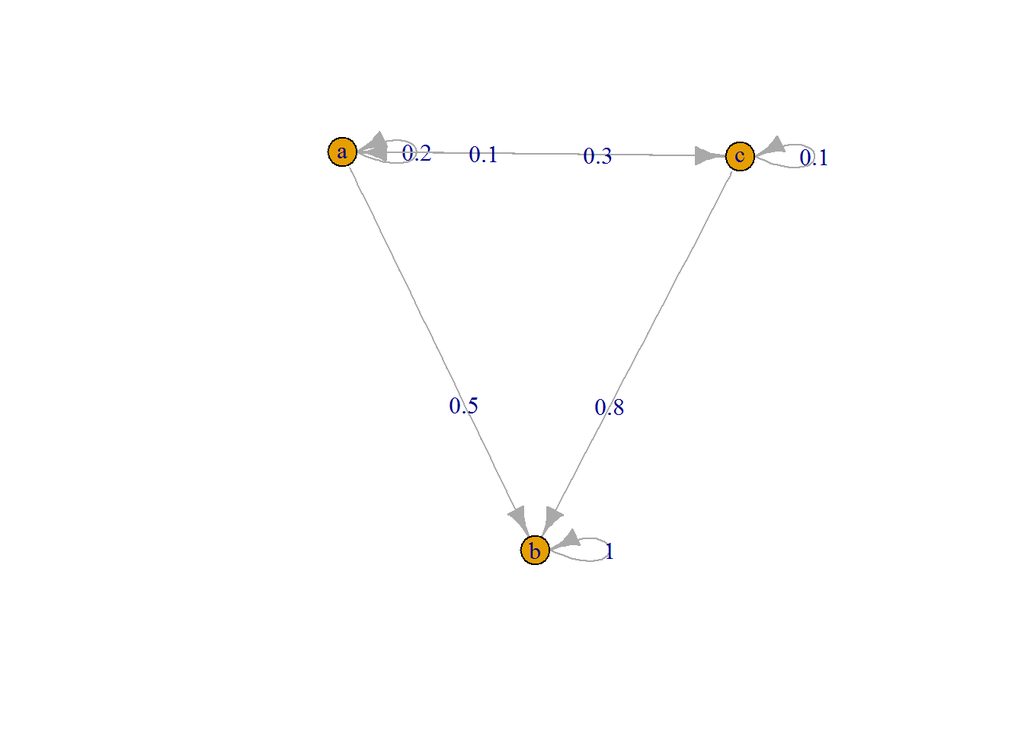

```r
plot(mcB)
```

```r
absorbingStates(mcB)
```

```
## [1] "b"
```

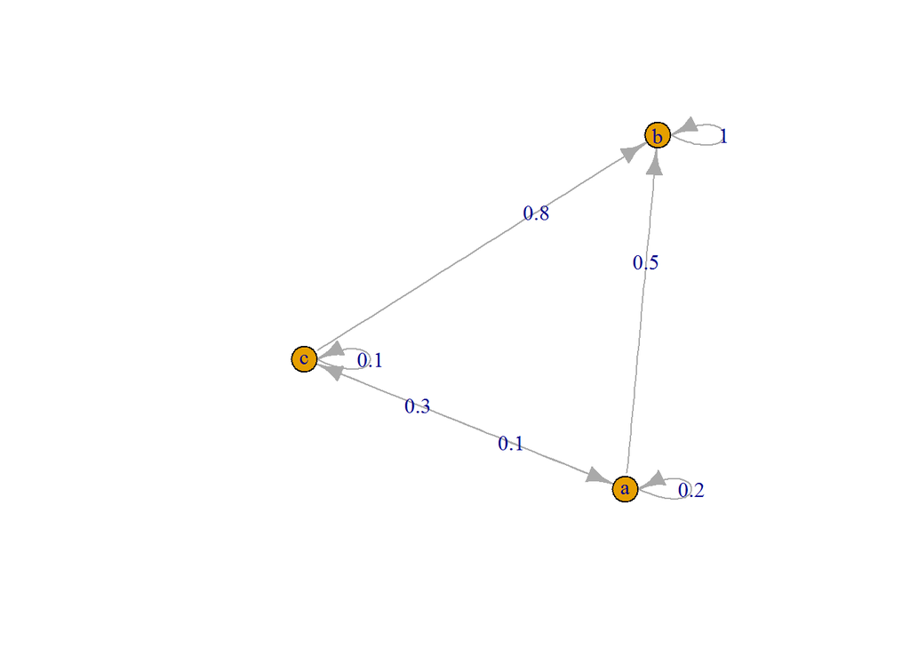

```r
plot(mcB)
```

```r
markovchainSequence(n=20, markovchain=mcC, include=TRUE)
```

```
##  [1] "a" "b" "b" "a" "b" "a" "b" "a" "b" "b" "b" "a" "b" "b" "a" "b" "b"
## [18] "b" "b" "b" "a"
```

### Various function to perform structural analysis of DTMC Example

```r
library("markovchain", lib.loc="~/R/win-library/3.2")
statesNames <- c("a", "b", "c")
markovB <- new("markovchain", states = statesNames, transitionMatrix =
matrix(c(0.2, 0.5, 0.3,
0, 1, 0,
0.1, 0.8, 0.1), nrow = 3, byrow = TRUE,
dimnames = list(statesNames, statesNames)
))
communicatingClasses(markovB)
```

```
## [[1]]
## [1] "a" "c"
##
## [[2]]
## [1] "b"
```

```r
recurrentClasses(markovB)
```

```
## [[1]]
## [1] "b"
```

```r
absorbingStates(markovB)
```

```
## [1] "b"
```

```r
transientStates(markovB)
```

```
## [1] "a" "c"
```

```r
canonicForm(markovB)
```

```
## Unnamed Markov chain
##  A  3 - dimensional discrete Markov Chain defined by the following states:
##  b, a, c
##  The transition matrix  (by rows)  is defined as follows:
##     b   a   c
## b 1.0 0.0 0.0
## a 0.5 0.2 0.3
## c 0.8 0.1 0.1
```

```r
# periodicity analysis : 1
E <- matrix(c(0, 1, 0, 0, 0.5, 0, 0.5, 0, 0, 0.5, 0, 0.5, 0, 0, 1, 0),
nrow = 4, ncol = 4, byrow = TRUE)
mcE <- new("markovchain", states = c("a", "b", "c", "d"),
transitionMatrix = E,
name = "E")
is.irreducible(mcE) #true
```

```
## [1] TRUE
```

```r
period(mcE) #2
```

```
## [1] 2
```

```r
# periodicity analysis : 2
myMatr <- matrix(c(0, 0, 1/2, 1/4, 1/4, 0, 0,
0, 0, 1/3, 0, 2/3, 0, 0,
0, 0, 0, 0, 0, 1/3, 2/3,
0, 0, 0, 0, 0, 1/2, 1/2,
0, 0, 0, 0, 0, 3/4, 1/4,
1/2, 1/2, 0, 0, 0, 0, 0,
1/4, 3/4, 0, 0, 0, 0, 0), byrow = TRUE, ncol = 7)
myMc <- new("markovchain", transitionMatrix = myMatr)
period(myMc)
```

```
## [1] 3
```

### Mobility between income quartiles Example

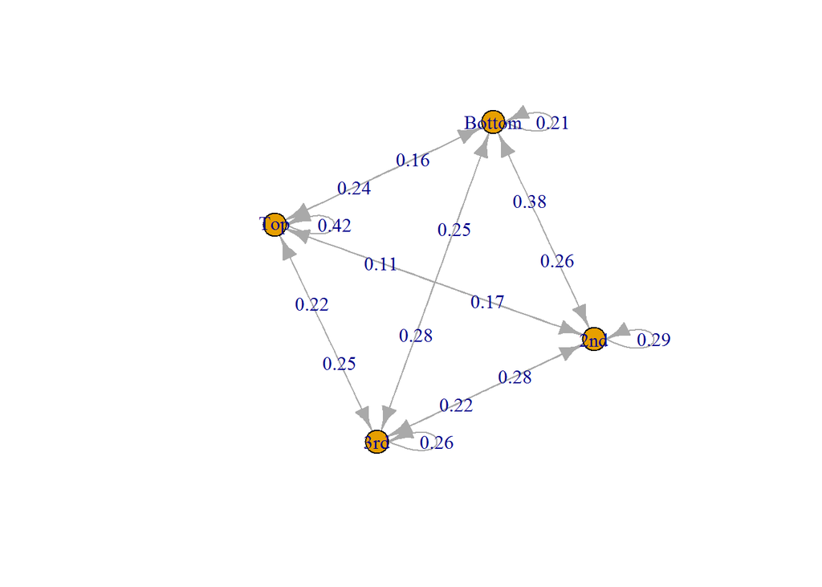

```r
library("markovchain", lib.loc="~/R/win-library/3.2")
data(blanden)
mobilityMc<-as(blanden, "markovchain")
plot(mobilityMc)
```

###conditionalDistribution of a Markov Chain Example It extracts the conditional distribution of the subsequent state, given current state.

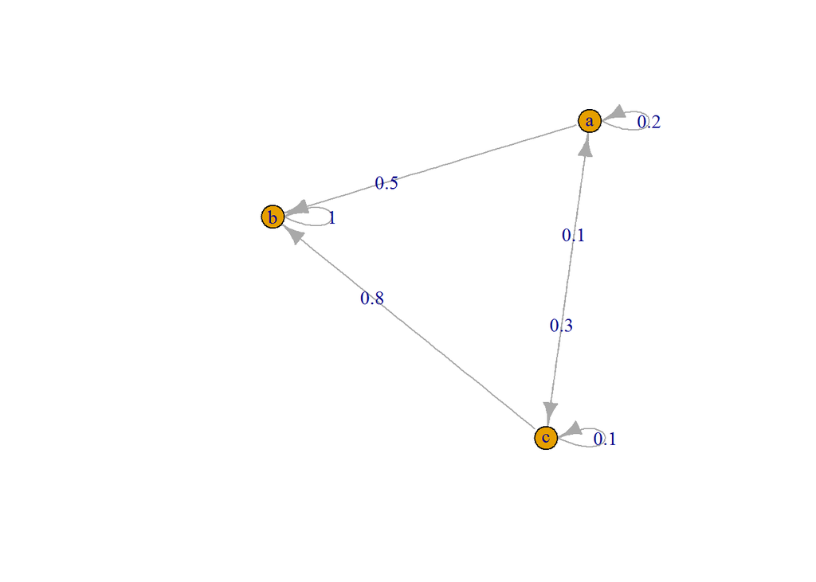

```r
library("markovchain", lib.loc="~/R/win-library/3.2")
# define a markov chain
statesNames <- c("a", "b", "c")
markovB <- new("markovchain", states = statesNames, transitionMatrix =
matrix(c(0.2, 0.5, 0.3, 0, 1, 0, 0.1, 0.8, 0.1),nrow = 3,
byrow = TRUE, dimnames = list(statesNames, statesNames)))
plot(markovB)
```

```r
conditionalDistribution(markovB, "b")
```

```
## a b c
## 0 1 0
```

### CD4 cells counts on HIV Infects between zero and six month Example

```r
library("markovchain", lib.loc="~/R/win-library/3.2")
data(craigsendi)
csMc<-as(craigsendi, "markovchain")
steadyStates(csMc)
```

```
##           0-49      50-74      75-UP
## [1,] 0.8343668 0.07659214 0.08904103
```

### Function to fit a discrete Markov chain Example

Given a sequence of states arising from a stationary state, it fits the underlying Markov chain distribution using either MLE (also using a Laplacian smoother), bootstrap or by MAP (Bayesian) inference.

```r
library("markovchain", lib.loc="~/R/win-library/3.2")
sequence <- c("a", "b", "a", "a", "a", "a", "b", "a", "b", "a", "b", "a", "a",
"b", "b", "b", "a")
sequenceMatr <- createSequenceMatrix(sequence, sanitize = FALSE)
mcFitMLE <- markovchainFit(data = sequence)
mcFitBSP <- markovchainFit(data = sequence, method = "bootstrap", nboot = 5, name = "Bootstrap Mc")
mcFitBSP
```

```
## $estimate
## Bootstrap Mc
##  A  2 - dimensional discrete Markov Chain defined by the following states:
##  a, b
##  The transition matrix  (by rows)  is defined as follows:
##           a         b
## a 0.3207937 0.6792063
## b 0.6345238 0.3654762
##
##
## $standardError
##            a          b
## a 0.08765671 0.08765671
## b 0.03647989 0.03647989
##
## $confidenceInterval
## $confidenceInterval$confidenceLevel
## [1] 0.95
##
## $confidenceInterval$lowerEndpointMatrix
##           a         b
## a 0.1766112 0.5350239
## b 0.5745197 0.3054721
##
## $confidenceInterval$upperEndpointMatrix
##           a         b
## a 0.4649761 0.8233888
## b 0.6945279 0.4254803
##
##
## $bootStrapSamples
## $bootStrapSamples[[1]]
##           a         b
## a 0.1666667 0.8333333
## b 0.5000000 0.5000000
##
## $bootStrapSamples[[2]]
##           a         b
## a 0.6000000 0.4000000
## b 0.6666667 0.3333333
##
## $bootStrapSamples[[3]]
##           a         b
## a 0.4444444 0.5555556
## b 0.7142857 0.2857143
##
## $bootStrapSamples[[4]]
##           a         b
## a 0.1428571 0.8571429
## b 0.6666667 0.3333333
##
## $bootStrapSamples[[5]]
##       a     b
## a 0.250 0.750
## b 0.625 0.375
##
##
## $logLikelihood
## [1] -10.76949
```

```r
mcFitMLE
```

```
## $estimate
## MLE Fit
##  A  2 - dimensional discrete Markov Chain defined by the following states:
##  a, b
##  The transition matrix  (by rows)  is defined as follows:
##           a         b
## a 0.4444444 0.5555556
## b 0.7142857 0.2857143
##
##
## $standardError
##           a         b
## a 0.2222222 0.2484520
## b 0.3194383 0.2020305
##
## $confidenceInterval
## $confidenceInterval$confidenceLevel
## [1] 0.95
##
## $confidenceInterval$lowerEndpointMatrix
##            a         b
## a 0.07892142 0.1468884
## b 0.18885650 0.0000000
##
## $confidenceInterval$upperEndpointMatrix
##           a         b
## a 0.8099675 0.9642227
## b 1.0000000 0.6180249
##
##
## $logLikelihood
## [1] -10.37054
```

### Class “ctmc” Example

```r
library("markovchain", lib.loc="~/R/win-library/3.2")
energyStates <- c("sigma", "sigma_star")
byRow <- TRUE
gen <- matrix(data = c(-3, 3,
1, -1), nrow = 2,
byrow = byRow, dimnames = list(energyStates, energyStates))
molecularCTMC <- new("ctmc", states = energyStates,
byrow = byRow, generator = gen,
name = "Molecular Transition Model")
steadyStates(molecularCTMC)
```

```
##      sigma sigma_star
## [1,]  0.25       0.75
```

### Function to fit a CTMC Example

```r
library("markovchain", lib.loc="~/R/win-library/3.2")
data <- list(c("a", "b", "c", "a", "b", "a", "c", "b", "c"), c(0, 0.8, 2.1, 2.4, 4, 5, 5.9, 8.2, 9))
ctmcFit(data)
```

```
## $estimate
## An object of class "ctmc"
## Slot "states":
## [1] "a" "b" "c"
##
## Slot "byrow":
## [1] TRUE
##
## Slot "generator":
##            a          b          c
## a -0.9090909  0.6060606  0.3030303
## b  0.3225806 -0.9677419  0.6451613
## c  0.3846154  0.3846154 -0.7692308
##
## Slot "name":
## [1] ""
##
##
## $errors
## $errors$dtmcConfidenceInterval
## $errors$dtmcConfidenceInterval$confidenceLevel
## [1] 0.95
##
## $errors$dtmcConfidenceInterval$lowerEndpointMatrix
##   a b c
## a 0 0 0
## b 0 0 0
## c 0 0 0
##
## $errors$dtmcConfidenceInterval$upperEndpointMatrix
##           a b         c
## a 0.0000000 1 0.8816179
## b 0.8816179 0 1.0000000
## c 1.0000000 1 0.0000000
##
##
## $errors$lambdaConfidenceInterval
## $errors$lambdaConfidenceInterval$lowerEndpointVector
## [1] 0.04576665 0.04871934 0.00000000
##
## $errors$lambdaConfidenceInterval$upperEndpointVector
## [1] 1 1 1
```

### First passage across states Example

```r
library("markovchain", lib.loc="~/R/win-library/3.2")
simpleMc <- new("markovchain", states = c("a", "b"),
transitionMatrix = matrix(c(0.4, 0.6, .3, .7),
nrow = 2, byrow = TRUE))
firstPassage(simpleMc, "b", 20)
```

```
##               a            b
## 1  0.3000000000 7.000000e-01
## 2  0.2100000000 1.800000e-01
## 3  0.1470000000 7.200000e-02
## 4  0.1029000000 2.880000e-02
## 5  0.0720300000 1.152000e-02
## 6  0.0504210000 4.608000e-03
## 7  0.0352947000 1.843200e-03
## 8  0.0247062900 7.372800e-04
## 9  0.0172944030 2.949120e-04
## 10 0.0121060821 1.179648e-04
## 11 0.0084742575 4.718592e-05
## 12 0.0059319802 1.887437e-05
## 13 0.0041523862 7.549747e-06
## 14 0.0029066703 3.019899e-06
## 15 0.0020346692 1.207960e-06
## 16 0.0014242685 4.831838e-07
## 17 0.0009969879 1.932735e-07
## 18 0.0006978915 7.730941e-08
## 19 0.0004885241 3.092376e-08
## 20 0.0003419669 1.236951e-08
```

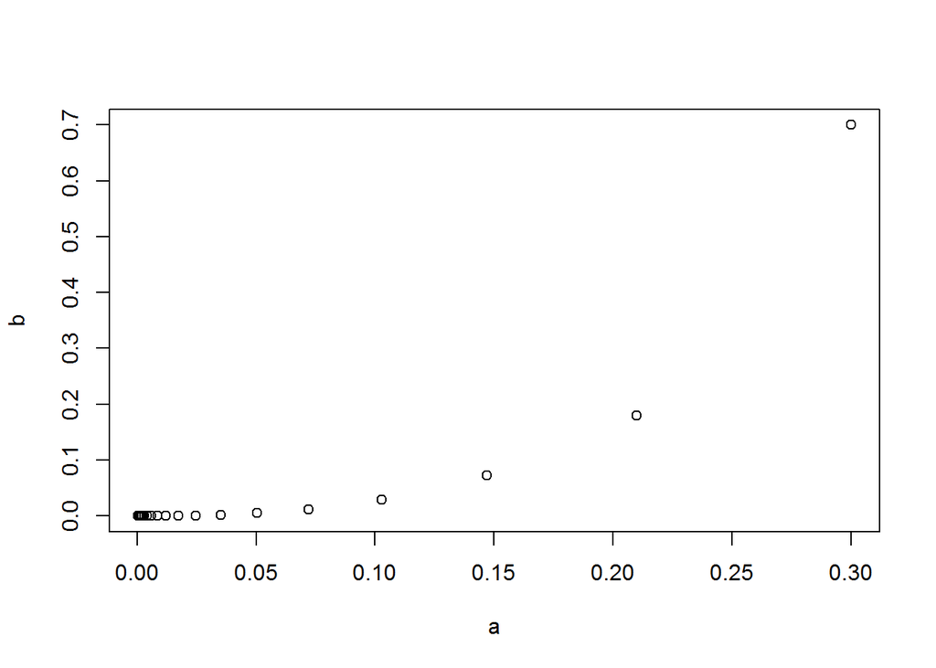

```r
plot(firstPassage(simpleMc, "b", 20))
```

### Functions to fit a higher order Markov chain Example

```r
library("markovchain", lib.loc="~/R/win-library/3.2")
library("Rsolnp", lib.loc="~/R/win-library/3.2")
sequence<-c("a", "a", "b", "b", "a", "c", "b", "a", "b", "c", "a", "b", "c", "a"
, "b", "c", "a", "b", "a", "b")
fitHigherOrder(sequence)
```

```
## $lambda
## [1] 1.000000e+00 1.626306e-08
##
## $Q
## $Q[[1]]
##       a         b    c
## a 0.125 0.4285714 0.75
## b 0.750 0.1428571 0.25
## c 0.125 0.4285714 0.00
##
## $Q[[2]]
##           a         b    c
## a 0.1428571 0.5714286 0.25
## b 0.4285714 0.2857143 0.75
## c 0.4285714 0.1428571 0.00
##
##
## $X
##   a   b   c
## 0.4 0.4 0.2
```

### Function to obtain the transition matrix from the generator Example

```r
library("markovchain", lib.loc="~/R/win-library/3.2")
energyStates <- c("sigma", "sigma_star")
byRow <- TRUE
gen <- matrix(data = c(-3, 3,
1, -1), nrow = 2,
byrow = byRow, dimnames = list(energyStates, energyStates))
generatorToTransitionMatrix(gen)
```

```
##            sigma sigma_star
## sigma          0          1
## sigma_star     1          0
```

### Class “HigherOrderMarkovChain” Example

```r
library("markovchain", lib.loc="~/R/win-library/3.2")
data(holson)
head(holson)
```

```
##   id time1 time2 time3 time4 time5 time6 time7 time8 time9 time10 time11
## 1  1     1     1     1     1     1     1     1     1     1      1      1
## 2  2     1     1     1     1     1     1     1     1     1      1      1
## 3  3     1     1     1     1     1     1     1     1     1      1      1
## 4  4     1     1     1     1     2     1     1     1     1      1      1
## 5  5     1     1     1     1     1     1     1     1     1      1      1
## 6  6     1     1     1     1     1     1     1     1     1      1      1
```

### Function to infer the hyperparameters for Bayesian inference from an a priori matrix or a data set Example

Since the Bayesian inference approach implemented in the package is based on conjugate priors, hyperparameters must be provided to model the prior probability distribution of the chain parameters. The hyperparameters are inferred from a given a priori matrix under the assumption that the matrix provided corresponds to the mean (expected) values of the chain parameters. A scaling factor vector must be provided too. Alternatively, the hyperparameters can be inferred from a data set.

```r
library("markovchain", lib.loc="~/R/win-library/3.2")
data(rain, package = "markovchain")
inferHyperparam(data = rain$rain)
```

```
## $dataInference
##       0 1-5  6+
## 0   363 127  61
## 1-5 137  91  69
## 6+   51  80 125
```

```r
weatherStates <- c("sunny", "cloudy", "rain")
weatherMatrix <- matrix(data = c(0.7, 0.2, 0.1,
0.3, 0.4, 0.3,
0.2, 0.4, 0.4),
byrow = TRUE, nrow = 3,
dimnames = list(weatherStates, weatherStates))
inferHyperparam(transMatr = weatherMatrix, scale = c(10, 10, 10))
```

```
## $scaledInference
##        cloudy rain sunny
## cloudy      4    3     3
## rain        4    4     2
## sunny       2    1     7
```

### Verify if a state j is reachable from state i. Example

```r
library("markovchain", lib.loc="~/R/win-library/3.2")
statesNames <- c("a", "b", "c")
markovB <- new("markovchain", states = statesNames,
transitionMatrix = matrix(c(0.2, 0.5, 0.3,
0, 1, 0,
0.1, 0.8, 0.1), nrow = 3, byrow = TRUE,
dimnames = list(statesNames, statesNames)
)
)
is.accessible(markovB, "a", "c")
```

```
## [1] TRUE
```

### Function to check if a Markov chain is irreducible Example

```r
library("markovchain", lib.loc="~/R/win-library/3.2")
statesNames <- c("a", "b")
mcA <- new("markovchain", transitionMatrix = matrix(c(0.7,0.3,0.1,0.9),
byrow = TRUE, nrow = 2,
dimnames = list(statesNames, statesNames)
))
is.irreducible(mcA)
```

```
## [1] TRUE
```

### Class “markovchain” Example

```r
library("markovchain", lib.loc="~/R/win-library/3.2")
#show markovchain definition
showClass("markovchain")
```

```
## Class "markovchain" [package "markovchain"]
##
## Slots:
##
## Name:            states            byrow transitionMatrix             name
## Class:        character          logical           matrix        character
```

```r
#create a simple Markov chain
transMatr<-matrix(c(0.4,0.6,.3,.7),nrow=2,byrow=TRUE)
simpleMc<-new("markovchain", states=c("a","b"),
transitionMatrix=transMatr,
name="simpleMc")
#power
simpleMc^4
```

```
## simpleMc^4
##  A  2 - dimensional discrete Markov Chain defined by the following states:
##  a, b
##  The transition matrix  (by rows)  is defined as follows:
##        a      b
## a 0.3334 0.6666
## b 0.3333 0.6667
```

```r
#some methods
steadyStates(simpleMc)
```

```
##              a         b
## [1,] 0.3333333 0.6666667
```

```r
absorbingStates(simpleMc)
```

```
## character(0)
```

```r
simpleMc[2,1]
```

```
## [1] 0.3
```

```r
t(simpleMc)
```

```
## Unnamed Markov chain
##  A  2 - dimensional discrete Markov Chain defined by the following states:
##  a, b
##  The transition matrix  (by cols)  is defined as follows:
##     a   b
## a 0.4 0.3
## b 0.6 0.7
```

```r
is.irreducible(simpleMc)
```

```
## [1] TRUE
```

```r
#conditional distributions
conditionalDistribution(simpleMc, "b")
```

```
##   a   b
## 0.3 0.7
```

```r
#example for predict method
sequence<-c("a", "b", "a", "a", "a", "a", "b", "a", "b", "a", "b", "a", "a", "b", "b", "b", "a")
mcFit<-markovchainFit(data=sequence)
predict(mcFit$estimate, newdata="b",n.ahead=3)
```

```
## [1] "a" "b" "a"
```

```r
#direct conversion
myMc<-as(transMatr, "markovchain")
#example of summary
summary(simpleMc)
```

```
## simpleMc  Markov chain that is composed by:
## Closed classes:
## a b
## Recurrent classes:
## {a,b}
## Transient classes:
## NONE
## The Markov chain is irreducible
## The absorbing states are: NONE
```

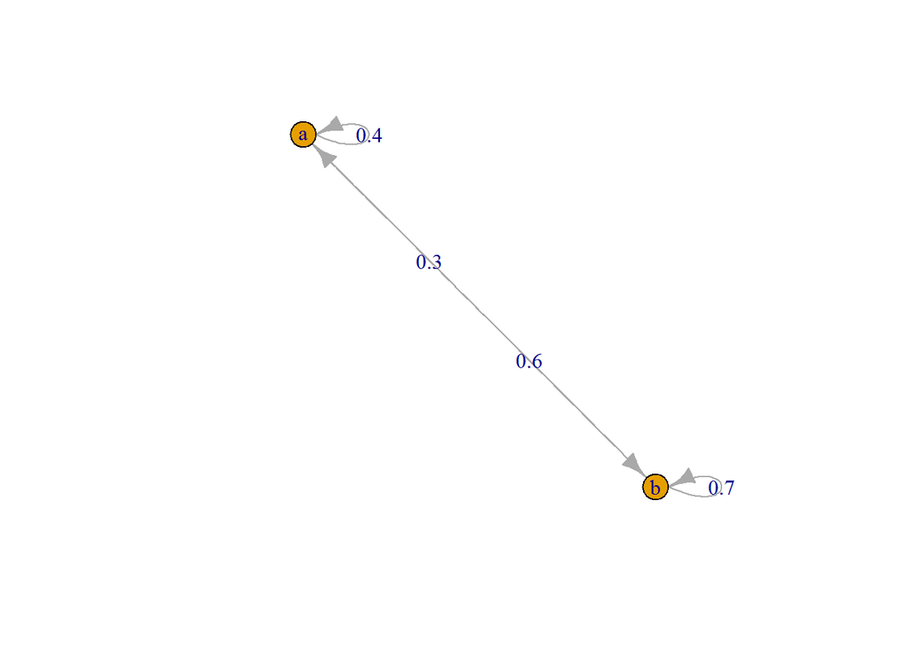

```r
## Not run: plot(simpleMc)
plot(simpleMc)
```

### Class “markovchainList” Example

```r
library("markovchain", lib.loc="~/R/win-library/3.2")
showClass("markovchainList")
```

```
## Class "markovchainList" [package "markovchain"]
##
## Slots:
##
## Name:  markovchains         name
## Class:         list    character
```

```r
#define a markovchainList
statesNames=c("a","b")
mcA<-new("markovchain",name="MCA", transitionMatrix=matrix(c(0.7,0.3,0.1,0.9),
byrow=TRUE, nrow=2, dimnames=list(statesNames,statesNames)))
mcB<-new("markovchain", states=c("a","b","c"), name="MCB",
transitionMatrix=matrix(c(0.2,0.5,0.3,0,1,0,0.1,0.8,0.1),
nrow=3, byrow=TRUE))
mcC<-new("markovchain", states=c("a","b","c","d"), name="MCC",
transitionMatrix=matrix(c(0.25,0.75,0,0,0.4,0.6,
0,0,0,0,0.1,0.9,0,0,0.7,0.3), nrow=4, byrow=TRUE)
)
mcList<-new("markovchainList",markovchains=list(mcA, mcB, mcC),
name="Non - homogeneous Markov Chain")
```

### markovchainListFit Example

```r
library("markovchain", lib.loc="~/R/win-library/3.2")
# using holson dataset
data(holson)
# fitting a single markovchain
singleMc <- markovchainFit(data = holson[,2:12])
# fitting a markovchainList
mclistFit <- markovchainListFit(data = holson[, 2:12], name = "holsonMcList")
```

### Function to generate a sequence of states from homogeneous Markov chains. Example

```r
library("markovchain", lib.loc="~/R/win-library/3.2")
# define the markovchain object
statesNames <- c("a", "b", "c")
mcB <- new("markovchain", states = statesNames,
transitionMatrix = matrix(c(0.2, 0.5, 0.3, 0, 0.2, 0.8, 0.1, 0.8, 0.1),
nrow = 3, byrow = TRUE, dimnames = list(statesNames, statesNames)))
# show the sequence
outs <- markovchainSequence(n = 100, markovchain = mcB, t0 = "a")
```

### A function to compute multinomial confidence intervals of DTMC Example

```r
library("markovchain", lib.loc="~/R/win-library/3.2")
seq<-c("a", "b", "a", "a", "a", "a", "b", "a", "b", "a", "b", "a", "a", "b", "b", "b", "a")
mcfit<-markovchainFit(data=seq,byrow=TRUE)
seqmat<-createSequenceMatrix(seq)
multinomialConfidenceIntervals(mcfit$estimate@transitionMatrix, seqmat, 0.95)
```

```
## $confidenceLevel
## [1] 0.95
##
## $lowerEndpointMatrix
##           a         b
## a 0.2222222 0.3333333
## b 0.5714286 0.1428571
##
## $upperEndpointMatrix
##           a         b
## a 0.8111456 0.9222567
## b 1.0000000 0.6839473
```

### Method to retrieve name of markovchain object Example

```r
library("markovchain", lib.loc="~/R/win-library/3.2")
statesNames <- c("a", "b", "c")
markovB <- new("markovchain", states = statesNames, transitionMatrix =
matrix(c(0.2, 0.5, 0.3, 0, 1, 0, 0.1, 0.8, 0.1), nrow = 3,
byrow = TRUE, dimnames=list(statesNames,statesNames)),
name = "A markovchain Object"
)
name(markovB)
```

```
## [1] "A markovchain Object"
```

```r
statesNames <- c("a", "b", "c")
markovB <- new("markovchain", states = statesNames, transitionMatrix =
matrix(c(0.2, 0.5, 0.3, 0, 1, 0, 0.1, 0.8, 0.1), nrow = 3,
byrow = TRUE, dimnames=list(statesNames,statesNames)),
name = "A markovchain Object"
)
name(markovB) <- "dangerous mc"
```

### Function to compute the probability of observing a new data set, given a data set Example

```r
library("markovchain", lib.loc="~/R/win-library/3.2")
sequence<-c("a", "b", "a", "a", "a", "a", "b", "a", "b", "a", "b", "a", "a",
"b", "b", "b", "a")
hyperMatrix<-matrix(c(1, 2, 1, 4), nrow = 2,dimnames=list(c("a","b"),c("a","b")))
predProb <- predictiveDistribution(sequence[1:10], sequence[11:17], hyperparam =hyperMatrix )
hyperMatrix2<-hyperMatrix[c(2,1),c(2,1)]
predProb2 <- predictiveDistribution(sequence[1:10], sequence[11:17], hyperparam =hyperMatrix2 )
predProb2==predProb
```

```
## [1] TRUE
```

### Preprogluccacon DNA protein bases sequences Example

```r
library("markovchain", lib.loc="~/R/win-library/3.2")
data(preproglucacon)
preproglucaconMc<-markovchainFit(data=preproglucacon$preproglucacon)
```

### Prior Distribution Example

```r
library("markovchain", lib.loc="~/R/win-library/3.2")
priorDistribution(matrix(c(0.5, 0.5, 0.5, 0.5),
nrow = 2,
dimnames = list(c("a", "b"), c("a", "b"))),
matrix(c(2, 2, 2, 2),
nrow = 2,
dimnames = list(c("a", "b"), c("a", "b"))))
```

```
##         a         b
## 0.4054651 0.4054651
```

### Alofi island daily rainfall Example

```r
library("markovchain", lib.loc="~/R/win-library/3.2")
data(rain)
rainMc<-markovchainFit(data=rain$rain)
```

### Function to generate a sequence of random CTMC transitions Example

```r
library("markovchain", lib.loc="~/R/win-library/3.2")
energyStates <- c("sigma", "sigma_star")
byRow <- TRUE
gen <- matrix(data = c(-3, 3,
1, -1), nrow = 2,
byrow = byRow, dimnames = list(energyStates, energyStates))
molecularCTMC <- new("ctmc", states = energyStates,
byrow = byRow, generator = gen,
name = "Molecular Transition Model")
statesDist <- c(0.8, 0.2)
rctmc(n = Inf, ctmc = molecularCTMC, T = 1)
```

```
## [[1]]
## [1] "sigma_star" "sigma"      "sigma_star" "sigma"
##
## [[2]]
## [1] 0.0000000 0.5984182 0.6718881 0.9107087
```

```r
rctmc(n = 5, ctmc = molecularCTMC, initDist = statesDist, include.T0 = FALSE)
```

```
## [[1]]
## [1] "sigma_star" "sigma"      "sigma_star" "sigma"      "sigma_star"
##
## [[2]]
## [1] 0.6739431 1.5873830 1.8129148 3.3286412 3.7541661
```

### Function to generate a sequence of states from homogeneous or nonhomogeneous Markov chains Example

```r
library("markovchain", lib.loc="~/R/win-library/3.2")
# define the markovchain object
statesNames <- c("a", "b", "c")
mcB <- new("markovchain", states = statesNames,
transitionMatrix = matrix(c(0.2, 0.5, 0.3, 0, 0.2, 0.8, 0.1, 0.8, 0.1),
nrow = 3, byrow = TRUE, dimnames = list(statesNames, statesNames)))
# show the sequence
outs <- rmarkovchain(n = 100, object = mcB, what = "list")
#define markovchainList object
statesName = c("a", "b", "c")
mcA <- new("markovchain", states = statesNames, transitionMatrix =
matrix(c(0.2, 0.5, 0.3, 0, 0.2, 0.8, 0.1, 0.8, 0.1), nrow = 3,
byrow = TRUE, dimnames = list(statesNames, statesNames)))
mcB <- new("markovchain", states = statesNames, transitionMatrix =
matrix(c(0.2, 0.5, 0.3, 0, 0.2, 0.8, 0.1, 0.8, 0.1), nrow = 3,
byrow = TRUE, dimnames = list(statesNames, statesNames)))
mcC <- new("markovchain", states = statesNames, transitionMatrix =
matrix(c(0.2, 0.5, 0.3, 0, 0.2, 0.8, 0.1, 0.8, 0.1), nrow = 3,
byrow = TRUE, dimnames = list(statesNames, statesNames)))
mclist <- new("markovchainList", markovchains = list(mcA, mcB, mcC))
# show the list of sequence
rmarkovchain(100, mclist, "list")
```

```
## [[1]]
## [1] "c" "b" "c"
##
## [[2]]
## [1] "a" "a" "a"
##
## [[3]]
## [1] "b" "b" "b"
##
## [[4]]
## [1] "c" "b" "c"
##
## [[5]]
## [1] "b" "b" "c"
##
## [[6]]
## [1] "c" "c" "b"
##
## [[7]]
## [1] "c" "c" "b"
##
## [[8]]
## [1] "b" "c" "b"
##
## [[9]]
## [1] "c" "b" "c"
##
## [[10]]
## [1] "b" "b" "b"
##
## [[11]]
## [1] "c" "b" "c"
##
## [[12]]
## [1] "b" "c" "b"
##
## [[13]]
## [1] "c" "b" "b"
##
## [[14]]
```

[output cut: 244 more lines]

```
##
## [[96]]
## [1] "b" "c" "b"
##
## [[97]]
## [1] "b" "c" "c"
##
## [[98]]
## [1] "c" "b" "c"
##
## [[99]]
## [1] "b" "b" "c"
##
## [[100]]
## [1] "b" "c" "b"
```

### Sales Demand Sequences Example

```r
library("markovchain", lib.loc="~/R/win-library/3.2")
data("sales")
#fitHighOrderMultivarMC(seqMat = sales, order = 2, Norm = 2)
```

### Defined states of a transition matrix Example

```r
library("markovchain", lib.loc="~/R/win-library/3.2")
statesNames <- c("a", "b", "c")
markovB <- new("markovchain", states = statesNames, transitionMatrix =
matrix(c(0.2, 0.5, 0.3, 0, 1, 0, 0.1, 0.8, 0.1), nrow = 3,
byrow = TRUE, dimnames=list(statesNames,statesNames)),
name = "A markovchain Object"
)
states(markovB)
```

```
## [1] "a" "b" "c"
```

### SStationary states of a markovchain objeect Example

```r
library("markovchain", lib.loc="~/R/win-library/3.2")
statesNames <- c("a", "b", "c")
markovB <- new("markovchain", states = statesNames, transitionMatrix =
matrix(c(0.2, 0.5, 0.3, 0, 1, 0, 0.1, 0.8, 0.1), nrow = 3,
byrow = TRUE, dimnames=list(statesNames,statesNames)),
name = "A markovchain Object"
)
steadyStates(markovB)
```

```
##      a b c
## [1,] 0 1 0
```

### Function to get the transition probabilities from initial to subsequent states Example

```r
library("markovchain", lib.loc="~/R/win-library/3.2")
statesNames <- c("a", "b", "c")
markovB <- new("markovchain", states = statesNames, transitionMatrix =
matrix(c(0.2, 0.5, 0.3, 0, 1, 0, 0.1, 0.8, 0.1), nrow = 3,
byrow = TRUE, dimnames=list(statesNames,statesNames)),
name = "A markovchain Object"
)
transitionProbability(markovB,"b", "c")
```

```
## [1] 0
```

### Various functions to perform statistical inference of DTMC Example

```r
library("markovchain", lib.loc="~/R/win-library/3.2")
sequence <- c("a", "b", "a", "a", "a", "a", "b", "a", "b",
"a", "b", "a", "a", "b", "b", "b", "a")
mcFit <- markovchainFit(data = sequence, byrow = FALSE)
verifyMarkovProperty(sequence)
```

```
## $aa
## $aa$statistic
## X-squared
##         0
##
## $aa$parameter
## df
##  1
##
## $aa$p.value
## [1] 1
##
## $aa$method
## [1] "Pearson's Chi-squared test with Yates' continuity correction"
##
## $aa$data.name
## [1] "table"
##
## $aa$observed
##   SSO TSO-SSO
## a   2       2
## b   2       3
##
## $aa$expected
##        SSO  TSO-SSO
## a 1.777778 2.222222
## b 2.222222 2.777778
##
## $aa$residuals
##          SSO    TSO-SSO
## a  0.1666667 -0.1490712
## b -0.1490712  0.1333333
##
## $aa$stdres
##    SSO TSO-SSO
## a  0.3    -0.3
## b -0.3     0.3
##
## $aa$table
##   SSO TSO
```

[output cut: 119 more lines]

```
##
## $bb$residuals
##          SSO    TSO-SSO
## a -0.3585686  0.2267787
## b  0.5669467 -0.3585686
##
## $bb$stdres
##          SSO    TSO-SSO
## a -0.7937254  0.7937254
## b  0.7937254 -0.7937254
##
## $bb$table
##   SSO TSO
## a   1   5
## b   1   2
```

```r
assessOrder(sequence)
```

```
## The assessOrder test statistic is:  1.55307e-31  the Chi-Square d.f. are:  2  the p-value is:  1
```

```
## $statistic
## [1] 1.55307e-31
##
## $p.value
## [1] 1
```

```r
assessStationarity(sequence, 1)
```

```
## The assessStationarity test statistic is:  0.1960191  the Chi-Square d.f. are:  0  the p-value is:  0
```

```
## $statistic
## [1] 0.1960191
##
## $p.value
## [1] 0
```

```r
divergenceTest(sequence, mcFit$estimate@transitionMatrix)
```

```
## The Divergence test statistic is:  0  the Chi-Square d.f. are:  2  the p-value is:  1
```

```
## $statistic
## [1] 0
##
## $p.value
## [1] 1
```

### read from csv Example

```r
library("csvread", lib.loc="~/R/win-library/3.2")
cic = csvread("C:\\Users\\ricca\\Documents\\R\\intermmidiate-ud.csv", coltypes = c("string","double","double","integer","integer","integer","long","string","integer","string"),header = TRUE)
summary(cic)
```

```
##    "system"         "First*(vertices)" "First*(edges)"
##  Length:647761      Min.   :  55       Min.   :  177
##  Class :character   1st Qu.:1310       1st Qu.:16416
##  Mode  :character   Median :1747       Median :23013
##                     Mean   :1565       Mean   :20208
##                     3rd Qu.:1888       3rd Qu.:24709
##                     Max.   :2032       Max.   :26549
##  "Count(CorrelatedPackage)" "Count(UnstabeDependenciesPackage)"
##  Min.   :  1.00             Min.   :  1.00
##  1st Qu.: 59.00             1st Qu.: 59.00
##  Median : 81.00             Median : 81.00
##  Mean   : 72.89             Mean   : 72.89
##  3rd Qu.: 87.00             3rd Qu.: 87.00
##  Max.   :188.00             Max.   :188.00
##   "numcommit"      "Commit"       "commitdate"       "modification"
##  Min.   :    1   Length:647761    Length:647761      Min.   :  0.00000
##  1st Qu.: 3123   Class :int64     Class :character   1st Qu.:  0.00000
##  Median : 6304   Mode  :numeric   Mode  :character   Median :  0.00000
##  Mean   : 6309                                       Mean   :  0.07736
##  3rd Qu.: 9398                                       3rd Qu.:  0.00000
##  Max.   :12824                                       Max.   :135.00000
##   "package"
##  Length:647761
##  Class :character
##  Mode  :character
##
##
##
```

### read from csv read csv Example

```r
library("csvread", lib.loc="~/R/win-library/3.2")
cic = read.csv("C:\\Users\\ricca\\Documents\\R\\intermmidiate-ud.csv",header = TRUE, nrows = 10000)
summary(cic)
```

```
##                      system     First..vertices. First..edges.
##  freecol-git100unzippati:  59   Min.   :1778     Min.   :25064
##  freecol-git101unzippati:  59   1st Qu.:1779     1st Qu.:25107
##  freecol-git102unzippati:  59   Median :1780     Median :25139
##  freecol-git103unzippati:  59   Mean   :1780     Mean   :25135
##  freecol-git104unzippati:  59   3rd Qu.:1780     3rd Qu.:25156
##  freecol-git105unzippati:  59   Max.   :1783     Max.   :25195
##  (Other)                :9646
##  Count.CorrelatedPackage. Count.UnstabeDependenciesPackage.
##  Min.   :95.00            Min.   :95.00
##  1st Qu.:96.00            1st Qu.:96.00
##  Median :96.00            Median :96.00
##  Mean   :96.06            Mean   :96.06
##  3rd Qu.:96.00            3rd Qu.:96.00
##  Max.   :97.00            Max.   :97.00
##
##    numcommit          Commit                          commitdate
##  Min.   :  1.00   Min.   :1.083e+12   2004-04-22T22:01:19.0:  59
##  1st Qu.: 48.00   1st Qu.:1.090e+12   2004-04-24T21:37:13.0:  59
##  Median : 95.00   Median :1.093e+12   2004-04-25T00:54:47.0:  59
##  Mean   : 96.36   Mean   :1.092e+12   2004-04-25T01:14:04.0:  59
##  3rd Qu.:144.00   3rd Qu.:1.095e+12   2004-04-26T08:01:36.0:  59
##  Max.   :198.00   Max.   :1.097e+12   2004-04-26T22:28:01.0:  59
##                                       (Other)              :9646
##   modification                                        package
##  Min.   : 0.0000   src.net.sf.freecol                     : 170
##  1st Qu.: 0.0000   src.net.sf.freecol.client              : 170
##  Median : 0.0000   src.net.sf.freecol.client.control      : 170
##  Mean   : 0.1159   src.net.sf.freecol.client.gui          : 170
##  3rd Qu.: 0.0000   src.net.sf.freecol.client.gui.action   : 170
##  Max.   :33.0000   src.net.sf.freecol.client.gui.animation: 170
##                    (Other)                                :8980
```

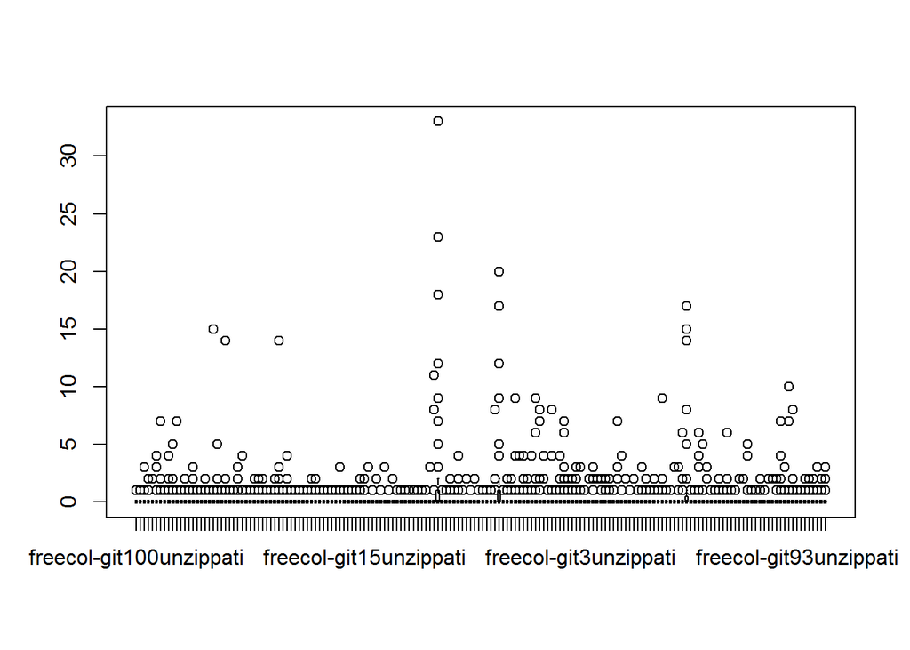

```r
plot(cic$sys,cic$modification)
```

### ddply example group

```r
library("plyr", lib.loc="~/R/win-library/3.2")
.(a, b, c)
```

```
## List of 3
##  $ a: symbol a
##  $ b: symbol b
##  $ c: symbol c
##  - attr(*, "env")=<environment: R_GlobalEnv>
##  - attr(*, "class")= chr "quoted"
```

```r
.(first = a, second = b, third = c)
```

```
## List of 3
##  $ first : symbol a
##  $ second: symbol b
##  $ third : symbol c
##  - attr(*, "env")=<environment: R_GlobalEnv>
##  - attr(*, "class")= chr "quoted"
```

```r
.(a ^ 2, b - d, log(c))
```

```
## List of 3
##  $ a^2   : language a^2
##  $ b - d : language b - d
##  $ log(c): language log(c)
##  - attr(*, "env")=<environment: R_GlobalEnv>
##  - attr(*, "class")= chr "quoted"
```

```r
as.quoted(~ a + b + c)
```

```
## List of 3
##  $ a: symbol a
##  $ b: symbol b
##  $ c: symbol c
##  - attr(*, "env")=<environment: R_GlobalEnv>
##  - attr(*, "class")= chr "quoted"
```

```r
as.quoted(a ~ b + c)
```

```
## List of 3
##  $ a: symbol a
##  $ b: symbol b
##  $ c: symbol c
##  - attr(*, "env")=<environment: R_GlobalEnv>
##  - attr(*, "class")= chr "quoted"
```

```r
as.quoted(c("a", "b", "c"))
```

```
## List of 3
##  $ a: symbol a
##  $ b: symbol b
##  $ c: symbol c
##  - attr(*, "env")=<environment: R_GlobalEnv>
##  - attr(*, "class")= chr "quoted"
```

```r
# Some examples using ddply - look at the column names
ddply(mtcars, "cyl", each(nrow, ncol))
```

```
##   cyl nrow ncol
## 1   4   11   11
## 2   6    7   11
## 3   8   14   11
```

```r
ddply(mtcars, ~ cyl, each(nrow, ncol))
```

```
##   cyl nrow ncol
## 1   4   11   11
## 2   6    7   11
## 3   8   14   11
```

```r
ddply(mtcars, .(cyl), each(nrow, ncol))
```

```
##   cyl nrow ncol
## 1   4   11   11
## 2   6    7   11
## 3   8   14   11
```

```r
ddply(mtcars, .(log(cyl)), each(nrow, ncol))
```

```
##   log(cyl) nrow ncol
## 1 1.386294   11   11
## 2 1.791759    7   11
## 3 2.079442   14   11
```

```r
ddply(mtcars, .(logcyl = log(cyl)), each(nrow, ncol))
```

```
##     logcyl nrow ncol
## 1 1.386294   11   11
## 2 1.791759    7   11
## 3 2.079442   14   11
```

```r
ddply(mtcars, .(vs + am), each(nrow, ncol))
```

```
##   vs + am nrow ncol
## 1       0   12   11
## 2       1   13   11
## 3       2    7   11
```

```r
ddply(mtcars, .(vsam = vs + am), each(nrow, ncol))
```

```
##   vsam nrow ncol
## 1    0   12   11
## 2    1   13   11
## 3    2    7   11
```

### ggplot example group

http://stackoverflow.com/questions/16961921/plot-data-in-descending-order-as-appears-in-data-frame

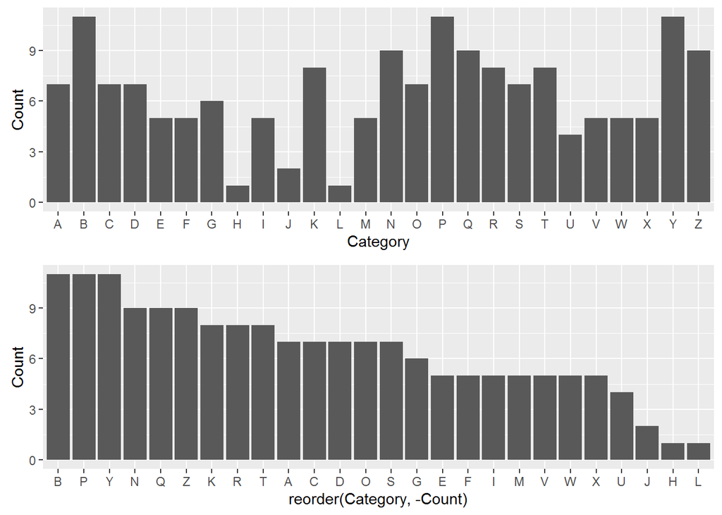

```r
set.seed(42)
df <- data.frame(Category = sample(LETTERS), Count = rpois(26, 6))
require("ggplot2")
p1 <- ggplot(df, aes(x = Category, y = Count)) +
         geom_bar(stat = "identity")
p2 <- ggplot(df, aes(x = reorder(Category, -Count), y = Count)) +
         geom_bar(stat = "identity")
require("gridExtra")
grid.arrange(arrangeGrob(p1, p2))
```

### ggplot example group

```r
library("csvread", lib.loc="~/R/win-library/3.2")
cic = read.csv("C:\\Users\\ricca\\Documents\\R\\intermmidiate-ud.csv",header = TRUE, nrows = 10000)
summary(cic)
```

```
##                      system     First..vertices. First..edges.
##  freecol-git100unzippati:  59   Min.   :1778     Min.   :25064
##  freecol-git101unzippati:  59   1st Qu.:1779     1st Qu.:25107
##  freecol-git102unzippati:  59   Median :1780     Median :25139
##  freecol-git103unzippati:  59   Mean   :1780     Mean   :25135
##  freecol-git104unzippati:  59   3rd Qu.:1780     3rd Qu.:25156
##  freecol-git105unzippati:  59   Max.   :1783     Max.   :25195
##  (Other)                :9646
##  Count.CorrelatedPackage. Count.UnstabeDependenciesPackage.
##  Min.   :95.00            Min.   :95.00
##  1st Qu.:96.00            1st Qu.:96.00
##  Median :96.00            Median :96.00
##  Mean   :96.06            Mean   :96.06
##  3rd Qu.:96.00            3rd Qu.:96.00
##  Max.   :97.00            Max.   :97.00
##
##    numcommit          Commit                          commitdate
##  Min.   :  1.00   Min.   :1.083e+12   2004-04-22T22:01:19.0:  59
##  1st Qu.: 48.00   1st Qu.:1.090e+12   2004-04-24T21:37:13.0:  59
##  Median : 95.00   Median :1.093e+12   2004-04-25T00:54:47.0:  59
##  Mean   : 96.36   Mean   :1.092e+12   2004-04-25T01:14:04.0:  59
##  3rd Qu.:144.00   3rd Qu.:1.095e+12   2004-04-26T08:01:36.0:  59
##  Max.   :198.00   Max.   :1.097e+12   2004-04-26T22:28:01.0:  59
##                                       (Other)              :9646
##   modification                                        package
##  Min.   : 0.0000   src.net.sf.freecol                     : 170
##  1st Qu.: 0.0000   src.net.sf.freecol.client              : 170
##  Median : 0.0000   src.net.sf.freecol.client.control      : 170
##  Mean   : 0.1159   src.net.sf.freecol.client.gui          : 170
##  3rd Qu.: 0.0000   src.net.sf.freecol.client.gui.action   : 170
##  Max.   :33.0000   src.net.sf.freecol.client.gui.animation: 170
##                    (Other)                                :8980
```

[figure not shown]

```r
require("ggplot2")
p1 <- ggplot(cic, aes(x = system, y = modification)) +
         geom_bar(stat = "identity") + theme(axis.text.x=element_text(angle = 90, hjust = 0.5))
p2 <- ggplot(cic, aes(x = reorder(system, Commit), y = modification)) +
         geom_bar(stat = "identity") + theme(axis.text.x=element_text(angle = 90, vjust = 0.5))
require("gridExtra")
grid.arrange(arrangeGrob(p1, p2))
```